# crunching_data

```python
import pandas as pd
import numpy as np
import matplotlib.pyplot as plt
```

## lecture des données

```python
df_cities = pd.read_csv('cities.csv')
df_cities.head()
```

|  | id | local_name | unique_name | latitude | longitude | population |
| --- | --- | --- | --- | --- | --- | --- |
| 0 | 5159 | Padua, Veneto, Italia | padua | 45.406435 | 11.876761 | 209678.0 |
| 1 | 76 | Barcelona, Cataluña, España | barcelona | 41.385064 | 2.173404 | 1611822.0 |
| 2 | 81 | Basel, Basel-Stadt, Schweiz | basel | 47.593437 | 7.619812 | NaN |
| 3 | 259 | Erlangen, Bayern, Deutschland | erlangen | 49.589674 | 11.011961 | 105412.0 |
| 4 | 11979 | Balș, Olt, România | balș | 44.353354 | 24.095672 | NaN |

#### df_cities est une dataframe qui contient les id des cities, leurs nom et leurs latitude et longitude

```python
df_providers = pd.read_csv('providers.csv')
df_providers
```

|  | id | company_id | provider_id | name | fullname | has_wifi | has_plug | has_adjustable_seats | has_bicycle | transport_type |
| --- | --- | --- | --- | --- | --- | --- | --- | --- | --- | --- |
| 0 | 9 | 1 | NaN | ouibus | Ouibus | True | True | True | False | bus |
| 1 | 10 | 2 | NaN | deinbus | Deinbus.de | False | False | False | False | bus |
| 2 | 11 | 3 | NaN | infobus | Infobus | False | False | False | False | bus |
| 3 | 12 | 4 | NaN | studentAgency | Student Agency | False | False | False | False | bus |
| 4 | 13 | 5 | NaN | flixbus | Flixbus | True | False | False | False | bus |
| 5 | 14 | 6 | NaN | driivme | DriiveMe | False | False | False | False | car |
| 6 | 15 | 8 | NaN | alsa | Alsa | False | False | False | False | bus |
| 7 | 16 | 9 | NaN | distribusion | Distribusion | False | False | False | False | bus |
| 8 | 17 | 9 | 31 | expressbusMunchen | Expressbus Munchen | False | False | False | False | bus |
| 9 | 18 | 9 | 33 | berlinLinienBus | Berlin Linien Bus | False | False | False | False | bus |
| 10 | 19 | 9 | 37 | ostfrieslandexpress | OstfrieslandExpress | False | False | False | False | bus |
| 11 | 20 | 9 | 41 | icBus | IC Bus | False | False | False | False | bus |
| 12 | 21 | 9 | 45 | busandfly | Busandfly | False | False | False | False | bus |
| 13 | 22 | 9 | 47 | publicexpress | Publicexpress | False | False | False | False | bus |
| 14 | 23 | 9 | 49 | hahnExpress | Hahn Express | False | False | False | False | bus |
| 15 | 24 | 9 | 57 | regionalverkehrErzgebirge | Regionalverkehr Erzgebirge | False | False | False | False | bus |
| 16 | 25 | 9 | 65 | autobusoberbayern | AutobusOberbayern | False | False | False | False | bus |
| 17 | 26 | 9 | 77 | schillingOmnibusverkehr | Schilling Omnibusverkehr | False | False | False | False | bus |
| 18 | 27 | 9 | 81 | kraftReisen | Kraft Reisen | False | False | False | False | bus |
| 19 | 28 | 9 | 83 | mayerMayer | Mayer Mayer | False | False | False | False | bus |
| 20 | 29 | 9 | 85 | ecolines | ECOLINES | False | False | False | False | bus |
| 21 | 30 | 9 | 111 | vogtlandFernbus | Vogtland Fernbus | False | False | False | False | bus |
| 22 | 31 | 9 | 115 | orlandREISEN | ORLAND REISEN | False | False | False | False | bus |
| 23 | 32 | 9 | 129 | postbus | Postbus | False | False | False | False | bus |
| 24 | 33 | 9 | 141 | expressbus | ExpressBus | False | False | False | False | bus |
| 25 | 34 | 9 | 149 | berlinShuttle | Berlin Shuttle | False | False | False | False | bus |
| 26 | 35 | 9 | 151 | matzesminibus | MatzesMinibus | False | False | False | False | bus |
| 27 | 36 | 9 | 159 | autotrans | Autotrans | False | False | False | False | bus |
| 28 | 37 | 9 | 161 | interbusKosiceExpress | Interbus Kosice Express | False | False | False | False | bus |
| 29 | 38 | 9 | 163 | nisEkspres | Nis Ekspres | False | False | False | False | bus |
| ... | ... | ... | ... | ... | ... | ... | ... | ... | ... | ... |
| 197 | 211 | 9 | 583 | estGdansk | EST Gdansk | False | False | False | False | bus |
| 198 | 212 | 9 | 589 | drdTurizem | DRD Turizem | False | False | False | False | bus |
| 199 | 214 | 9 | 593 | euroclub | Euroclub | False | False | False | False | bus |
| 200 | 215 | 9 | 595 | panturist | Panturist | False | False | False | False | bus |
| 201 | 216 | 9 | 597 | navettedeVatry | Navette de Vatry | False | False | False | False | bus |
| 202 | 217 | 9 | 599 | flybusIceland | Flybus Iceland | False | False | False | False | bus |
| 203 | 218 | 9 | 601 | smsFlughafentransfer | SMS Flughafentransfer | False | False | False | False | bus |
| 204 | 219 | 9 | 603 | airDecker | Air Decker | False | False | False | False | bus |
| 205 | 220 | 9 | 605 | eilatShuttle | Eilat Shuttle | False | False | False | False | bus |
| 206 | 221 | 9 | 607 | wagnerTransport | Wagner Transport | False | False | False | False | bus |
| 207 | 222 | 9 | 611 | fiumicinoExpress | Fiumicino Express | False | False | False | False | bus |
| 208 | 4511 | 10 | NaN | vsc | Voyages SNCF | False | False | False | False | train |
| 209 | 8371 | 20 | I | isilines | Isilines | True | True | True | False | bus |
| 210 | 8372 | 20 | E | eurolines | Eurolines | False | False | True | False | bus |
| 211 | 8373 | 20 | M | movelia | Movelia | False | False | False | False | bus |
| 212 | 8374 | 20 | NaN | transdev | Transdev | NaN | NaN | NaN | NaN | bus |
| 213 | 8375 | 10 | 0 | trainter | TER | False | False | True | False | train |
| 214 | 8376 | 10 | 1 | tgv | TGV | False | False | True | False | train |
| 215 | 8377 | 10 | 2 | corailintercite | Intercités | False | False | True | False | train |
| 216 | 8378 | 10 | 3 | tramtrain | Tramtrain | False | False | True | False | train |
| 217 | 8379 | 10 | 4 | navette | Navette Keolis | False | False | True | False | bus |
| 218 | 8380 | 10 | 5 | train | TER | False | False | True | False | train |
| 219 | 8381 | 10 | 6 | coraillunea | Intercités de Nuit | False | False | True | False | train |
| 220 | 8382 | 10 | 8 | eurostar | Eurostar | False | False | True | False | train |
| 221 | 8383 | 10 | 9 | corail | Intercités | False | False | True | False | train |
| 222 | 8384 | 10 | 16 | thalys | Thalys | True | True | False | True | train |
| 223 | 8385 | 11 | NaN | bbc | Blablacar | False | False | False | False | carpooling |
| 224 | 8387 | 30 | NaN | vatry | Vatry | NaN | NaN | NaN | NaN | bus |
| 225 | 8388 | 40 | NaN | beauval | Beauval | NaN | NaN | NaN | NaN | bus |
| 226 | 8389 | 12 | NaN | idvroom | idVroom | False | False | False | False | carpooling |

227 rows × 10 columns

##### dans la dataframe 'providers' on a tous les informations sur les companies comme le nom , type de transport, les services disponibles à bord

```python
df_stations = pd.read_csv('stations.csv')
df_stations.head()
```

|  | id | unique_name | latitude | longitude |
| --- | --- | --- | --- | --- |
| 0 | 1 | Aalen (Stuttgarter Straße) | 48.835296 | 10.092956 |
| 1 | 2 | Aéroport Bordeaux-Mérignac | 44.830226 | -0.700883 |
| 2 | 3 | Aéroport CDG | 49.009900 | 2.559310 |
| 3 | 4 | Aéroport de Berlin-Schönefeld | 52.389446 | 13.520345 |
| 4 | 5 | Aéroport de Dresden | 51.123604 | 13.764737 |

#### dans la dataframe 'stations' on a les noms des stations et leurs latitude et longitude

```python
df_ticket = pd.read_csv('ticket_data.csv')
df_ticket.head()
```

|  | id | company | o_station | d_station | departure_ts | arrival_ts | price_in_cents | search_ts | middle_stations | other_companies | o_city | d_city |
| --- | --- | --- | --- | --- | --- | --- | --- | --- | --- | --- | --- | --- |
| 0 | 6795025 | 8385 | NaN | NaN | 2017-10-13 14:00:00+00 | 2017-10-13 20:10:00+00 | 4550 | 2017-10-01 00:13:31.327+00 | NaN | NaN | 611 | 542 |
| 1 | 6795026 | 9 | 63.0 | 1044.0 | 2017-10-13 13:05:00+00 | 2017-10-14 06:55:00+00 | 1450 | 2017-10-01 00:13:35.773+00 | {149,418} | {13} | 611 | 542 |
| 2 | 6795027 | 8377 | 5905.0 | 6495.0 | 2017-10-13 13:27:00+00 | 2017-10-14 21:24:00+00 | 7400 | 2017-10-01 00:13:40.212+00 | {798,798,6794,6246} | {8377,8376} | 611 | 542 |
| 3 | 6795028 | 8377 | 5905.0 | 6495.0 | 2017-10-13 13:27:00+00 | 2017-10-14 11:02:00+00 | 13500 | 2017-10-01 00:13:40.213+00 | {798,798,6794,6246} | {8377,8376} | 611 | 542 |
| 4 | 6795029 | 8381 | 5905.0 | 6495.0 | 2017-10-13 21:46:00+00 | 2017-10-14 19:32:00+00 | 7710 | 2017-10-01 00:13:40.213+00 | {5983,5983} | {8380} | 611 | 542 |

#### on a une dataframe qui contient les informtions sur les trajets avec les heures de départ et de l'arrivée , les villes d'origine et les villes de destination.

## exploration des données

```python
df_ticket.columns
```

```
Index(['id', 'company', 'o_station', 'd_station', 'departure_ts', 'arrival_ts',
       'price_in_cents', 'search_ts', 'middle_stations', 'other_companies',
       'o_city', 'd_city'],
      dtype='object')
```

```python
print(df_ticket.dtypes)
```

```
id                   int64
company              int64
o_station          float64
d_station          float64
departure_ts        object
arrival_ts          object
price_in_cents       int64
search_ts           object
middle_stations     object
other_companies     object
o_city               int64
d_city               int64
dtype: object
```

##### il faut changer les types de departure_ts, arrival_ts, search_ts de objet à date

```python
df_ticket['departure_ts'] =  pd.to_datetime(df_ticket['departure_ts'],format='%Y%m%d %H:%M:%S.%f')
df_ticket['arrival_ts'] =  pd.to_datetime(df_ticket['arrival_ts'],format='%Y%m%d %H:%M:%S.%f')
df_ticket['search_ts'] =  pd.to_datetime(df_ticket['search_ts'],format='%Y%m%d %H:%M:%S.%f')
```

```python
print(df_ticket.dtypes)
```

```
id                          int64
company                     int64
o_station                 float64
d_station                 float64
departure_ts       datetime64[ns]
arrival_ts         datetime64[ns]
price_in_cents              int64
search_ts          datetime64[ns]
middle_stations            object
other_companies            object
o_city                      int64
d_city                      int64
dtype: object
```

```python
df_ticket['company'].nunique()
```

```
20
```

```python
df_ticket['o_city'].nunique()
```

```
306
```

```python
df_ticket['d_city'].nunique()
```

```
332
```

#### on a 306 cités d'orgine et 332 cités de destination

```python
df_ticket.groupby('o_city').count()
```

| o_city | id | company | o_station | d_station | departure_ts | arrival_ts | price_in_cents | search_ts | middle_stations | other_companies | d_city |
| --- | --- | --- | --- | --- | --- | --- | --- | --- | --- | --- | --- |
| 5 | 5 | 5 | 5 | 5 | 5 | 5 | 5 | 5 | 5 | 5 | 5 |
| 6 | 243 | 243 | 34 | 34 | 243 | 243 | 243 | 243 | 34 | 34 | 243 |
| 11 | 582 | 582 | 212 | 212 | 582 | 582 | 582 | 582 | 212 | 212 | 582 |
| 15 | 1 | 1 | 0 | 0 | 1 | 1 | 1 | 1 | 0 | 0 | 1 |
| 21 | 186 | 186 | 88 | 88 | 186 | 186 | 186 | 186 | 88 | 88 | 186 |
| 23 | 320 | 320 | 259 | 259 | 320 | 320 | 320 | 320 | 259 | 259 | 320 |
| 28 | 233 | 233 | 76 | 76 | 233 | 233 | 233 | 233 | 76 | 76 | 233 |
| 30 | 93 | 93 | 84 | 84 | 93 | 93 | 93 | 93 | 84 | 84 | 93 |
| 33 | 171 | 171 | 132 | 132 | 171 | 171 | 171 | 171 | 132 | 132 | 171 |
| 46 | 146 | 146 | 111 | 111 | 146 | 146 | 146 | 146 | 111 | 111 | 146 |
| 52 | 5 | 5 | 0 | 0 | 5 | 5 | 5 | 5 | 0 | 0 | 5 |
| 54 | 77 | 77 | 60 | 60 | 77 | 77 | 77 | 77 | 60 | 60 | 77 |
| 57 | 541 | 541 | 307 | 307 | 541 | 541 | 541 | 541 | 307 | 307 | 541 |
| 59 | 4 | 4 | 4 | 4 | 4 | 4 | 4 | 4 | 4 | 4 | 4 |
| 76 | 28 | 28 | 14 | 14 | 28 | 28 | 28 | 28 | 14 | 14 | 28 |
| 85 | 114 | 114 | 82 | 82 | 114 | 114 | 114 | 114 | 82 | 82 | 114 |
| 89 | 24 | 24 | 8 | 8 | 24 | 24 | 24 | 24 | 8 | 8 | 24 |
| 94 | 3 | 3 | 0 | 0 | 3 | 3 | 3 | 3 | 0 | 0 | 3 |
| 95 | 2 | 2 | 0 | 0 | 2 | 2 | 2 | 2 | 0 | 0 | 2 |
| 99 | 22 | 22 | 19 | 19 | 22 | 22 | 22 | 22 | 19 | 19 | 22 |
| 100 | 1 | 1 | 0 | 0 | 1 | 1 | 1 | 1 | 0 | 0 | 1 |
| 102 | 154 | 154 | 102 | 102 | 154 | 154 | 154 | 154 | 102 | 102 | 154 |
| 105 | 16 | 16 | 15 | 15 | 16 | 16 | 16 | 16 | 15 | 15 | 16 |
| 107 | 29 | 29 | 13 | 13 | 29 | 29 | 29 | 29 | 13 | 13 | 29 |
| 109 | 79 | 79 | 52 | 52 | 79 | 79 | 79 | 79 | 52 | 52 | 79 |
| 112 | 18 | 18 | 16 | 16 | 18 | 18 | 18 | 18 | 16 | 16 | 18 |
| 126 | 2388 | 2388 | 884 | 884 | 2388 | 2388 | 2388 | 2388 | 884 | 884 | 2388 |
| 132 | 51 | 51 | 48 | 48 | 51 | 51 | 51 | 51 | 48 | 48 | 51 |
| 134 | 237 | 237 | 216 | 216 | 237 | 237 | 237 | 237 | 216 | 216 | 237 |
| 143 | 1 | 1 | 1 | 1 | 1 | 1 | 1 | 1 | 1 | 1 | 1 |
| ... | ... | ... | ... | ... | ... | ... | ... | ... | ... | ... | ... |
| 9126 | 18 | 18 | 18 | 18 | 18 | 18 | 18 | 18 | 18 | 18 | 18 |
| 9141 | 12 | 12 | 0 | 0 | 12 | 12 | 12 | 12 | 0 | 0 | 12 |
| 9148 | 1 | 1 | 0 | 0 | 1 | 1 | 1 | 1 | 0 | 0 | 1 |
| 9151 | 13 | 13 | 11 | 11 | 13 | 13 | 13 | 13 | 11 | 11 | 13 |
| 9166 | 10 | 10 | 0 | 0 | 10 | 10 | 10 | 10 | 0 | 0 | 10 |
| 9170 | 1 | 1 | 0 | 0 | 1 | 1 | 1 | 1 | 0 | 0 | 1 |
| 9197 | 10 | 10 | 10 | 10 | 10 | 10 | 10 | 10 | 10 | 10 | 10 |
| 9251 | 2 | 2 | 2 | 2 | 2 | 2 | 2 | 2 | 2 | 2 | 2 |
| 9442 | 125 | 125 | 31 | 31 | 125 | 125 | 125 | 125 | 31 | 31 | 125 |
| 9645 | 12 | 12 | 7 | 7 | 12 | 12 | 12 | 12 | 7 | 7 | 12 |
| 9666 | 6 | 6 | 0 | 0 | 6 | 6 | 6 | 6 | 0 | 0 | 6 |
| 9687 | 12 | 12 | 0 | 0 | 12 | 12 | 12 | 12 | 0 | 0 | 12 |
| 9717 | 6 | 6 | 0 | 0 | 6 | 6 | 6 | 6 | 0 | 0 | 6 |
| 9742 | 27 | 27 | 7 | 7 | 27 | 27 | 27 | 27 | 7 | 7 | 27 |
| 9794 | 2 | 2 | 0 | 0 | 2 | 2 | 2 | 2 | 0 | 0 | 2 |
| 10006 | 7 | 7 | 0 | 0 | 7 | 7 | 7 | 7 | 0 | 0 | 7 |
| 10033 | 13 | 13 | 6 | 6 | 13 | 13 | 13 | 13 | 6 | 6 | 13 |
| 10480 | 2 | 2 | 0 | 0 | 2 | 2 | 2 | 2 | 0 | 0 | 2 |
| 10523 | 1 | 1 | 1 | 1 | 1 | 1 | 1 | 1 | 1 | 1 | 1 |
| 10719 | 235 | 235 | 15 | 15 | 235 | 235 | 235 | 235 | 15 | 15 | 235 |
| 10780 | 6 | 6 | 0 | 0 | 6 | 6 | 6 | 6 | 0 | 0 | 6 |
| 10814 | 3 | 3 | 0 | 0 | 3 | 3 | 3 | 3 | 0 | 0 | 3 |
| 10998 | 2 | 2 | 0 | 0 | 2 | 2 | 2 | 2 | 0 | 0 | 2 |
| 11185 | 2 | 2 | 0 | 0 | 2 | 2 | 2 | 2 | 0 | 0 | 2 |
| 11616 | 1 | 1 | 0 | 0 | 1 | 1 | 1 | 1 | 0 | 0 | 1 |
| 11835 | 29 | 29 | 9 | 9 | 29 | 29 | 29 | 29 | 9 | 9 | 29 |
| 11938 | 72 | 72 | 4 | 4 | 72 | 72 | 72 | 72 | 4 | 4 | 72 |
| 12124 | 2 | 2 | 1 | 1 | 2 | 2 | 2 | 2 | 1 | 1 | 2 |
| 12166 | 1 | 1 | 1 | 1 | 1 | 1 | 1 | 1 | 1 | 1 | 1 |
| 12190 | 19 | 19 | 1 | 1 | 19 | 19 | 19 | 19 | 1 | 1 | 19 |

306 rows × 11 columns

```python
df_ticket['o_city'].value_counts()
```

```
628      30425
485       6511
126       2388
562       1968
1061      1648
845       1641
453       1531
504       1515
227       1442
611       1237
317       1134
200       1109
876       1094
580        929
697        898
```

[output cut: 47 more lines]

### Prix

```python
df_ticket['price_in_cents'].describe()
```

```
count    74168.000000
mean      4382.711061
std       3739.325367
min        300.000000
25%       1900.000000
50%       3350.000000
75%       5250.000000
max      38550.000000
Name: price_in_cents, dtype: float64
```

#### on remarque que

```
 le prix minimum d'un trajet c'est 300 cent
 le prix maximum d'un trajet c'est 38550 cent
 le prix moyen d'un trajet c'est 4382 cent
```

```python
df_ticket['price_in_cents'].idxmax()
```

```
66513
```

```python
df_ticket.iloc[66513]
```

```
id                                    6861537
company                                  8382
o_station                                6057
d_station                                 860
departure_ts              2017-10-23 08:31:00
arrival_ts                2017-10-23 14:56:00
price_in_cents                          38550
search_ts          2017-10-18 08:35:13.593000
middle_stations                   {1898,6799}
other_companies                        {8376}
o_city                                    467
d_city                                    126
Name: 66513, dtype: object
```

```python
df_cities
```

|  | id | local_name | unique_name | latitude | longitude | population |
| --- | --- | --- | --- | --- | --- | --- |
| 0 | 5159 | Padua, Veneto, Italia | padua | 45.406435 | 11.876761 | 209678.0 |
| 1 | 76 | Barcelona, Cataluña, España | barcelona | 41.385064 | 2.173404 | 1611822.0 |
| 2 | 81 | Basel, Basel-Stadt, Schweiz | basel | 47.593437 | 7.619812 | NaN |
| 3 | 259 | Erlangen, Bayern, Deutschland | erlangen | 49.589674 | 11.011961 | 105412.0 |
| 4 | 11979 | Balș, Olt, România | balș | 44.353354 | 24.095672 | NaN |
| 5 | 10314 | Град Пожаревац, Централна Србија, Србија | град-пожаревац | 44.619095 | 21.176522 | NaN |
| 6 | 11155 | Bussy-Lettrée, Grand-Est, France | bussy-lettree | 48.804600 | 4.259500 | NaN |
| 7 | 11788 | Chamonix, Valle d'Aosta, Italia | chamonix-italia | 45.817156 | 6.952375 | NaN |
| 8 | 11984 | Borger, Texas, United States of America | borger | 35.667820 | -101.397388 | NaN |
| 9 | 11825 | okres Zvolen, Banskobystrický kraj, Slovensko | okres-zvolen | 48.576181 | 19.137116 | NaN |
| 10 | 11878 | Castellón de la Plana, Comunitat Valenciana, E... | castellon-de-la-plana | 40.004000 | -0.063400 | NaN |
| 11 | 11992 | Castello-Molina di Fiemme, Trentino-Alto Adige... | castello-molina-di-fiemme | 46.281845 | 11.437143 | NaN |
| 12 | 11998 | Craiova, Dolj, România | craiova | 44.330178 | 23.794881 | NaN |
| 13 | 12002 | Filiași, Dolj, România | filiași | 44.554523 | 23.520009 | NaN |
| 14 | 12005 | Gare de Lamarche, Grand-Est, France | gare-de-lamarche | 48.089980 | 5.760170 | NaN |
| 15 | 834 | Tignes Val Claret, Auvergne-Rhône-Alpes, France | tignes-val-claret | 45.457331 | 6.901682 | NaN |
| 16 | 10339 | Briançon - Serre-Chevalier, Provence-Alpes-Côt... | briancon---serre-chevalier | 44.897001 | 6.634323 | NaN |
| 17 | 10712 | Aix-la-Chapelle, Nordrhein-Westfalen, Deutschland | aix-la-chapelle | 50.785661 | 6.136859 | NaN |
| 18 | 5409 | Aarschot, Vlaanderen, Belgique | aarschot | 50.986000 | 4.836500 | NaN |
| 19 | 5439 | Aime - La Plagne, Auvergne-Rhône-Alpes, France | aime---la-plagne | 45.554500 | 6.648800 | NaN |
| 20 | 5423 | Agropoli Castellabate, CAM, Italia | agropoli-castellabate | 40.351400 | 15.001900 | NaN |
| 21 | 5445 | Aix En Provence Gare Routiere, Provence-Alpes-... | aix-en-provence-gare-routiere | 43.524900 | 5.454100 | NaN |
| 22 | 12014 | Huelva, Andalucía, España | huelva | 37.253100 | -6.950800 | NaN |
| 23 | 12015 | Hunedoara, Hunedoara, România | hunedoara | 45.767813 | 22.907233 | NaN |
| 24 | 12016 | Hymont, Grand-Est, France | hymont | 48.265700 | 6.141900 | NaN |
| 25 | 12017 | Ile de Ré Nouvelle-Aquitaine, France | ile-de-re-nouvelle-aquitaine | 46.228940 | -1.541300 | NaN |
| 26 | 12018 | Ile d'Oléron, Nouvelle-Aquitaine, France | ile-doleron | 45.943040 | -1.307410 | NaN |
| 27 | 5444 | Aix-en-Provence Centre, Provence-Alpes-Côte d'... | aix-en-provence-centre | 43.522900 | 5.445300 | NaN |
| 28 | 9378 | Ahun, Nouvelle-Aquitaine, France | ahun | 46.086460 | 2.045080 | NaN |
| 29 | 12023 | Jessains, Grand-Est, France | jessains | 48.297070 | 4.577940 | NaN |
| ... | ... | ... | ... | ... | ... | ... |
| 8010 | 163 | Budapest, Közép-Magyarország, Magyarország | budapest | 47.497912 | 19.040235 | 1735711.0 |
| 8011 | 317 | Grenoble, Auvergne-Rhône-Alpes, France | grenoble | 45.188529 | 5.724524 | 160779.0 |
| 8012 | 389 | Katowice, Sląskie, Polska | katowice | 50.264892 | 19.023782 | 304362.0 |
| 8013 | 1285 | Aberdeen, Scotland, UK | aberdeen | 57.145245 | -2.091374 | 195021.0 |
| 8014 | 1317 | Aveiro, Centro, Portugal | aveiro | 40.635252 | -8.660895 | NaN |
| 8015 | 1433 | Bristol, England, UK | bristol | 51.453493 | -2.597394 | 535907.0 |
| 8016 | 1508 | Cheltenham, England, UK | cheltenham | 51.899569 | -2.071156 | 116447.0 |
| 8017 | 2106 | Newcastle upon Tyne, England, UK | newcastle-upon-tyne | 54.977092 | -1.614206 | 268064.0 |
| 8018 | 5739 | Belgrade, Централна Србија, Serbia | belgrade | 44.804400 | 20.461100 | NaN |
| 8019 | 10299 | South Oxfordshire, England, UK | south-oxfordshire | 51.636609 | -1.080473 | NaN |
| 8020 | 10326 | Cologno Monzese, LOM, Italia | cologno-monzese | 45.528156 | 9.277699 | NaN |
| 8021 | 10586 | Ciutadella, Illes Balears, 124 | ciutadella | 40.000677 | 3.835597 | NaN |
| 8022 | 7711 | Monaco - Monte-Carlo, , Monaco - Monte-Carlo | monaco---monte-carlo | 43.738740 | 7.419400 | NaN |
| 8023 | 913 | Wien, Wien, Österreich | wien | 48.208174 | 16.373819 | NaN |
| 8024 | 33 | Annecy, Auvergne-Rhône-Alpes, France | annecy | 45.899247 | 6.129384 | NaN |
| 8025 | 485 | Lyon, Auvergne-Rhône-Alpes, France | lyon | 45.764043 | 4.835659 | 506615.0 |
| 8026 | 1477 | Cardiff, Wales, UK | cardiff | 51.481655 | -3.179193 | 335145.0 |
| 8027 | 1993 | Lublin, lubelskie, Polska | lublin | 51.247235 | 22.555546 | NaN |
| 8028 | 2126 | Norwich, England, UK | norwich | 52.628606 | 1.292270 | 186682.0 |
| 8029 | 2133 | Novi Sad, Војводина, Serbia | novi-sad | 45.255105 | 19.845081 | NaN |
| 8030 | 2249 | Portsmouth, England, UK | portsmouth | 50.803683 | -1.075614 | 238137.0 |
| 8031 | 2448 | Southampton, England, UK | southampton | 50.902535 | -1.404189 | 253651.0 |
| 8032 | 10601 | Funchal, Madeira, Arquipelago da Madeira (Port... | funchal | 32.649650 | -16.908678 | 108469.0 |
| 8033 | 9457 | Brême, Brême, Deutschland | breme | 53.081900 | 8.813300 | NaN |
| 8034 | 7523 | Malaga, Andalucía, España | malaga | 36.711120 | -4.431860 | 568479.0 |
| 8035 | 9964 | Saint-André-lez-Lille, Hauts-de-France, France | saint-andre-lez-lille | 50.654250 | 3.047690 | NaN |
| 8036 | 10863 | Kiev, Шевченківський район, Ukraine | kiev | 50.450100 | 30.523400 | NaN |
| 8037 | 11144 | Brighton, England, UK | brighton | 50.822000 | -0.137400 | NaN |
| 8038 | 11377 | Manises, Comunitat Valenciana, España | manises | 39.493000 | -0.462100 | NaN |
| 8039 | 11537 | South Cambridgeshire, England, UK | south-cambridgeshire | 52.179600 | -0.003400 | NaN |

8040 rows × 6 columns

```python
df_cities.loc[df_cities['id'] == 467]
```

|  | id | local_name | unique_name | latitude | longitude | population |
| --- | --- | --- | --- | --- | --- | --- |
| 556 | 467 | London, England, United Kingdom | london | 51.507351 | -0.127758 | 8416535.0 |

```python
df_cities.loc[df_cities['id'] == 126]
```

|  | id | local_name | unique_name | latitude | longitude | population |
| --- | --- | --- | --- | --- | --- | --- |
| 8006 | 126 | Bordeaux, Nouvelle-Aquitaine, France | bordeaux | 44.83357 | -0.573845 | 246586.0 |

```python
df_providers
```

|  | id | company_id | provider_id | name | fullname | has_wifi | has_plug | has_adjustable_seats | has_bicycle | transport_type |
| --- | --- | --- | --- | --- | --- | --- | --- | --- | --- | --- |
| 0 | 9 | 1 | NaN | ouibus | Ouibus | True | True | True | False | bus |
| 1 | 10 | 2 | NaN | deinbus | Deinbus.de | False | False | False | False | bus |
| 2 | 11 | 3 | NaN | infobus | Infobus | False | False | False | False | bus |
| 3 | 12 | 4 | NaN | studentAgency | Student Agency | False | False | False | False | bus |
| 4 | 13 | 5 | NaN | flixbus | Flixbus | True | False | False | False | bus |
| 5 | 14 | 6 | NaN | driivme | DriiveMe | False | False | False | False | car |
| 6 | 15 | 8 | NaN | alsa | Alsa | False | False | False | False | bus |
| 7 | 16 | 9 | NaN | distribusion | Distribusion | False | False | False | False | bus |
| 8 | 17 | 9 | 31 | expressbusMunchen | Expressbus Munchen | False | False | False | False | bus |
| 9 | 18 | 9 | 33 | berlinLinienBus | Berlin Linien Bus | False | False | False | False | bus |
| 10 | 19 | 9 | 37 | ostfrieslandexpress | OstfrieslandExpress | False | False | False | False | bus |
| 11 | 20 | 9 | 41 | icBus | IC Bus | False | False | False | False | bus |
| 12 | 21 | 9 | 45 | busandfly | Busandfly | False | False | False | False | bus |
| 13 | 22 | 9 | 47 | publicexpress | Publicexpress | False | False | False | False | bus |
| 14 | 23 | 9 | 49 | hahnExpress | Hahn Express | False | False | False | False | bus |
| 15 | 24 | 9 | 57 | regionalverkehrErzgebirge | Regionalverkehr Erzgebirge | False | False | False | False | bus |
| 16 | 25 | 9 | 65 | autobusoberbayern | AutobusOberbayern | False | False | False | False | bus |
| 17 | 26 | 9 | 77 | schillingOmnibusverkehr | Schilling Omnibusverkehr | False | False | False | False | bus |
| 18 | 27 | 9 | 81 | kraftReisen | Kraft Reisen | False | False | False | False | bus |
| 19 | 28 | 9 | 83 | mayerMayer | Mayer Mayer | False | False | False | False | bus |
| 20 | 29 | 9 | 85 | ecolines | ECOLINES | False | False | False | False | bus |
| 21 | 30 | 9 | 111 | vogtlandFernbus | Vogtland Fernbus | False | False | False | False | bus |
| 22 | 31 | 9 | 115 | orlandREISEN | ORLAND REISEN | False | False | False | False | bus |
| 23 | 32 | 9 | 129 | postbus | Postbus | False | False | False | False | bus |
| 24 | 33 | 9 | 141 | expressbus | ExpressBus | False | False | False | False | bus |
| 25 | 34 | 9 | 149 | berlinShuttle | Berlin Shuttle | False | False | False | False | bus |
| 26 | 35 | 9 | 151 | matzesminibus | MatzesMinibus | False | False | False | False | bus |
| 27 | 36 | 9 | 159 | autotrans | Autotrans | False | False | False | False | bus |
| 28 | 37 | 9 | 161 | interbusKosiceExpress | Interbus Kosice Express | False | False | False | False | bus |
| 29 | 38 | 9 | 163 | nisEkspres | Nis Ekspres | False | False | False | False | bus |
| ... | ... | ... | ... | ... | ... | ... | ... | ... | ... | ... |
| 197 | 211 | 9 | 583 | estGdansk | EST Gdansk | False | False | False | False | bus |
| 198 | 212 | 9 | 589 | drdTurizem | DRD Turizem | False | False | False | False | bus |
| 199 | 214 | 9 | 593 | euroclub | Euroclub | False | False | False | False | bus |
| 200 | 215 | 9 | 595 | panturist | Panturist | False | False | False | False | bus |
| 201 | 216 | 9 | 597 | navettedeVatry | Navette de Vatry | False | False | False | False | bus |
| 202 | 217 | 9 | 599 | flybusIceland | Flybus Iceland | False | False | False | False | bus |
| 203 | 218 | 9 | 601 | smsFlughafentransfer | SMS Flughafentransfer | False | False | False | False | bus |
| 204 | 219 | 9 | 603 | airDecker | Air Decker | False | False | False | False | bus |
| 205 | 220 | 9 | 605 | eilatShuttle | Eilat Shuttle | False | False | False | False | bus |
| 206 | 221 | 9 | 607 | wagnerTransport | Wagner Transport | False | False | False | False | bus |
| 207 | 222 | 9 | 611 | fiumicinoExpress | Fiumicino Express | False | False | False | False | bus |
| 208 | 4511 | 10 | NaN | vsc | Voyages SNCF | False | False | False | False | train |
| 209 | 8371 | 20 | I | isilines | Isilines | True | True | True | False | bus |
| 210 | 8372 | 20 | E | eurolines | Eurolines | False | False | True | False | bus |
| 211 | 8373 | 20 | M | movelia | Movelia | False | False | False | False | bus |
| 212 | 8374 | 20 | NaN | transdev | Transdev | NaN | NaN | NaN | NaN | bus |
| 213 | 8375 | 10 | 0 | trainter | TER | False | False | True | False | train |
| 214 | 8376 | 10 | 1 | tgv | TGV | False | False | True | False | train |
| 215 | 8377 | 10 | 2 | corailintercite | Intercités | False | False | True | False | train |
| 216 | 8378 | 10 | 3 | tramtrain | Tramtrain | False | False | True | False | train |
| 217 | 8379 | 10 | 4 | navette | Navette Keolis | False | False | True | False | bus |
| 218 | 8380 | 10 | 5 | train | TER | False | False | True | False | train |
| 219 | 8381 | 10 | 6 | coraillunea | Intercités de Nuit | False | False | True | False | train |
| 220 | 8382 | 10 | 8 | eurostar | Eurostar | False | False | True | False | train |
| 221 | 8383 | 10 | 9 | corail | Intercités | False | False | True | False | train |
| 222 | 8384 | 10 | 16 | thalys | Thalys | True | True | False | True | train |
| 223 | 8385 | 11 | NaN | bbc | Blablacar | False | False | False | False | carpooling |
| 224 | 8387 | 30 | NaN | vatry | Vatry | NaN | NaN | NaN | NaN | bus |
| 225 | 8388 | 40 | NaN | beauval | Beauval | NaN | NaN | NaN | NaN | bus |
| 226 | 8389 | 12 | NaN | idvroom | idVroom | False | False | False | False | carpooling |

227 rows × 10 columns

```python
df_providers.loc[df_providers['id'] == 8382 ]
```

|  | id | company_id | provider_id | name | fullname | has_wifi | has_plug | has_adjustable_seats | has_bicycle | transport_type |
| --- | --- | --- | --- | --- | --- | --- | --- | --- | --- | --- |
| 220 | 8382 | 10 | 8 | eurostar | Eurostar | False | False | True | False | train |

#### le prix maximum d'un trajet est 38550 cent avec la companie'8382' qui offre un trajet de London, England, United Kingdom vers Bordeaux, Nouvelle-Aquitaine, France par train

```python
df_ticket.iloc[df_ticket['price_in_cents'].idxmin()]
```

```
id                                    6799150
company                                  8385
o_station                                 NaN
d_station                                 NaN
departure_ts              2017-10-06 18:00:00
arrival_ts                2017-10-06 18:50:00
price_in_cents                            300
search_ts          2017-10-02 17:05:42.424000
middle_stations                           NaN
other_companies                           NaN
o_city                                     54
d_city                                   6211
Name: 4125, dtype: object
```

```python
df_cities.loc[df_cities['id'] == 54]
```

|  | id | local_name | unique_name | latitude | longitude | population |
| --- | --- | --- | --- | --- | --- | --- |
| 5393 | 54 | Auxerre, Bourgogne-Franche-Comté, France | auxerre | 47.796629 | 3.584484 | NaN |

```python
df_cities.loc[df_cities['id'] == 6211]
```

|  | id | local_name | unique_name | latitude | longitude | population |
| --- | --- | --- | --- | --- | --- | --- |
| 6100 | 6211 | Clamecy, Bourgogne-Franche-Comté, France | clamecy | 47.4668 | 3.5208 | NaN |

```python
df_providers.loc[df_providers['id'] == 8385 ]
```

|  | id | company_id | provider_id | name | fullname | has_wifi | has_plug | has_adjustable_seats | has_bicycle | transport_type |
| --- | --- | --- | --- | --- | --- | --- | --- | --- | --- | --- |
| 223 | 8385 | 11 | NaN | bbc | Blablacar | False | False | False | False | carpooling |

#### le prix minmum d'un trajet est 300 cent avec la companie'8385' qui offre un trajet de Auxerre, Bourgogne-Franche-Comté, France vers Clamecy, Bourgogne-Franche-Comté, France par carpooling

### Durée

#### on a crée une colone dont la quelle on a calculé la différence entre la date d'arrivée et la date de départ

```python
df_ticket['duree'] = (df_ticket['arrival_ts']- df_ticket['departure_ts'])/np.timedelta64(1,'s')

df_ticket
```

|  | id | company | o_station | d_station | departure_ts | arrival_ts | price_in_cents | search_ts | middle_stations | other_companies | o_city | d_city | duree |
| --- | --- | --- | --- | --- | --- | --- | --- | --- | --- | --- | --- | --- | --- |
| 0 | 6795025 | 8385 | NaN | NaN | 2017-10-13 14:00:00 | 2017-10-13 20:10:00 | 4550 | 2017-10-01 00:13:31.327 | NaN | NaN | 611 | 542 | 22200.0 |
| 1 | 6795026 | 9 | 63.0 | 1044.0 | 2017-10-13 13:05:00 | 2017-10-14 06:55:00 | 1450 | 2017-10-01 00:13:35.773 | {149,418} | {13} | 611 | 542 | 64200.0 |
| 2 | 6795027 | 8377 | 5905.0 | 6495.0 | 2017-10-13 13:27:00 | 2017-10-14 21:24:00 | 7400 | 2017-10-01 00:13:40.212 | {798,798,6794,6246} | {8377,8376} | 611 | 542 | 115020.0 |
| 3 | 6795028 | 8377 | 5905.0 | 6495.0 | 2017-10-13 13:27:00 | 2017-10-14 11:02:00 | 13500 | 2017-10-01 00:13:40.213 | {798,798,6794,6246} | {8377,8376} | 611 | 542 | 77700.0 |
| 4 | 6795029 | 8381 | 5905.0 | 6495.0 | 2017-10-13 21:46:00 | 2017-10-14 19:32:00 | 7710 | 2017-10-01 00:13:40.213 | {5983,5983} | {8380} | 611 | 542 | 78360.0 |
| 5 | 6795030 | 8385 | NaN | NaN | 2017-10-06 05:30:00 | 2017-10-06 08:30:00 | 1800 | 2017-10-01 01:03:18.948 | NaN | NaN | 628 | 453 | 10800.0 |
| 6 | 6795031 | 8385 | NaN | NaN | 2017-10-06 07:00:42 | 2017-10-06 09:30:42 | 2150 | 2017-10-01 01:03:18.948 | NaN | NaN | 628 | 453 | 9000.0 |
| 7 | 6795032 | 8385 | NaN | NaN | 2017-10-06 07:10:00 | 2017-10-06 09:40:00 | 1700 | 2017-10-01 01:03:18.948 | NaN | NaN | 628 | 453 | 9000.0 |
| 8 | 6795033 | 8385 | NaN | NaN | 2017-10-06 10:00:00 | 2017-10-06 12:50:00 | 1700 | 2017-10-01 01:03:18.948 | NaN | NaN | 628 | 453 | 10200.0 |
| 9 | 6795034 | 8385 | NaN | NaN | 2017-10-06 10:00:00 | 2017-10-06 12:50:00 | 1900 | 2017-10-01 01:03:18.948 | NaN | NaN | 628 | 453 | 10200.0 |
| 10 | 6795035 | 8385 | NaN | NaN | 2017-10-06 12:40:00 | 2017-10-06 15:40:00 | 1550 | 2017-10-01 01:03:18.948 | NaN | NaN | 628 | 453 | 10800.0 |
| 11 | 6795036 | 8385 | NaN | NaN | 2017-10-06 13:00:00 | 2017-10-06 15:40:00 | 1450 | 2017-10-01 01:03:18.948 | NaN | NaN | 628 | 453 | 9600.0 |
| 12 | 6795037 | 8385 | NaN | NaN | 2017-10-06 13:00:00 | 2017-10-06 15:30:00 | 1550 | 2017-10-01 01:03:18.948 | NaN | NaN | 628 | 453 | 9000.0 |
| 13 | 6795038 | 8385 | NaN | NaN | 2017-10-06 13:00:00 | 2017-10-06 15:30:00 | 1550 | 2017-10-01 01:03:18.948 | NaN | NaN | 628 | 453 | 9000.0 |
| 14 | 6795039 | 8385 | NaN | NaN | 2017-10-06 13:00:00 | 2017-10-06 15:30:00 | 1800 | 2017-10-01 01:03:18.950 | NaN | NaN | 628 | 453 | 9000.0 |
| 15 | 6795040 | 8385 | NaN | NaN | 2017-10-06 13:40:00 | 2017-10-06 16:30:00 | 1700 | 2017-10-01 01:03:18.950 | NaN | NaN | 628 | 453 | 10200.0 |
| 16 | 6795041 | 8385 | NaN | NaN | 2017-10-06 14:00:16 | 2017-10-06 16:30:16 | 1700 | 2017-10-01 01:03:18.950 | NaN | NaN | 628 | 453 | 9000.0 |
| 17 | 6795042 | 8385 | NaN | NaN | 2017-10-06 14:00:00 | 2017-10-06 17:00:00 | 1800 | 2017-10-01 01:03:18.950 | NaN | NaN | 628 | 453 | 10800.0 |
| 18 | 6795043 | 8385 | NaN | NaN | 2017-10-06 14:00:00 | 2017-10-06 17:20:00 | 1900 | 2017-10-01 01:03:18.950 | NaN | NaN | 628 | 453 | 12000.0 |
| 19 | 6795044 | 8385 | NaN | NaN | 2017-10-06 14:00:00 | 2017-10-06 16:40:00 | 2300 | 2017-10-01 01:03:18.950 | NaN | NaN | 628 | 453 | 9600.0 |
| 20 | 6795045 | 8385 | NaN | NaN | 2017-10-06 14:50:00 | 2017-10-06 17:40:00 | 1700 | 2017-10-01 01:03:18.950 | NaN | NaN | 628 | 453 | 10200.0 |
| 21 | 6795046 | 8385 | NaN | NaN | 2017-10-06 15:10:00 | 2017-10-06 17:50:00 | 1800 | 2017-10-01 01:03:18.950 | NaN | NaN | 628 | 453 | 9600.0 |
| 22 | 6795047 | 8385 | NaN | NaN | 2017-10-06 15:30:00 | 2017-10-06 17:50:00 | 1450 | 2017-10-01 01:03:18.950 | NaN | NaN | 628 | 453 | 8400.0 |
| 23 | 6795048 | 8385 | NaN | NaN | 2017-10-06 15:50:00 | 2017-10-06 18:50:00 | 1700 | 2017-10-01 01:03:18.950 | NaN | NaN | 628 | 453 | 10800.0 |
| 24 | 6795049 | 8385 | NaN | NaN | 2017-10-06 15:50:00 | 2017-10-06 18:50:00 | 1800 | 2017-10-01 01:03:18.950 | NaN | NaN | 628 | 453 | 10800.0 |
| 25 | 6795050 | 8385 | NaN | NaN | 2017-10-06 16:00:00 | 2017-10-06 19:00:00 | 1700 | 2017-10-01 01:03:18.950 | NaN | NaN | 628 | 453 | 10800.0 |
| 26 | 6795051 | 8385 | NaN | NaN | 2017-10-06 16:00:00 | 2017-10-06 19:00:00 | 1800 | 2017-10-01 01:03:18.950 | NaN | NaN | 628 | 453 | 10800.0 |
| 27 | 6795052 | 8385 | NaN | NaN | 2017-10-06 16:00:00 | 2017-10-06 18:50:00 | 1800 | 2017-10-01 01:03:18.951 | NaN | NaN | 628 | 453 | 10200.0 |
| 28 | 6795053 | 8385 | NaN | NaN | 2017-10-06 16:50:00 | 2017-10-06 19:20:00 | 1550 | 2017-10-01 01:03:18.951 | NaN | NaN | 628 | 453 | 9000.0 |
| 29 | 6795054 | 8385 | NaN | NaN | 2017-10-06 17:00:00 | 2017-10-06 19:30:00 | 1300 | 2017-10-01 01:03:18.951 | NaN | NaN | 628 | 453 | 9000.0 |
| ... | ... | ... | ... | ... | ... | ... | ... | ... | ... | ... | ... | ... | ... |
| 74138 | 6869163 | 8385 | NaN | NaN | 2017-10-27 18:00:00 | 2017-10-27 22:20:00 | 3000 | 2017-10-19 10:35:31.269 | NaN | NaN | 628 | 562 | 15600.0 |
| 74139 | 6869164 | 8385 | NaN | NaN | 2017-10-27 18:30:00 | 2017-10-27 22:30:00 | 2900 | 2017-10-19 10:35:31.269 | NaN | NaN | 628 | 562 | 14400.0 |
| 74140 | 6869165 | 8385 | NaN | NaN | 2017-10-27 18:30:00 | 2017-10-27 22:50:00 | 2900 | 2017-10-19 10:35:31.269 | NaN | NaN | 628 | 562 | 15600.0 |
| 74141 | 6869166 | 8385 | NaN | NaN | 2017-10-27 18:30:00 | 2017-10-27 23:10:00 | 3000 | 2017-10-19 10:35:31.269 | NaN | NaN | 628 | 562 | 16800.0 |
| 74142 | 6869167 | 8385 | NaN | NaN | 2017-10-27 19:10:00 | 2017-10-27 23:00:00 | 2650 | 2017-10-19 10:35:31.269 | NaN | NaN | 628 | 562 | 13800.0 |
| 74143 | 6869168 | 8385 | NaN | NaN | 2017-10-27 21:20:00 | 2017-10-28 01:10:00 | 2900 | 2017-10-19 10:35:31.269 | NaN | NaN | 628 | 562 | 13800.0 |
| 74144 | 6869169 | 8385 | NaN | NaN | 2017-10-27 21:50:00 | 2017-10-28 01:40:00 | 3600 | 2017-10-19 10:35:31.269 | NaN | NaN | 628 | 562 | 13800.0 |
| 74145 | 6869170 | 8376 | 767.0 | 6591.0 | 2017-10-27 06:38:00 | 2017-10-27 23:02:00 | 1950 | 2017-10-19 10:35:40.167 | {408,408} | {8377} | 628 | 562 | 59040.0 |
| 74146 | 6869175 | 8376 | 767.0 | 6591.0 | 2017-10-27 16:38:00 | 2017-10-27 19:16:00 | 8020 | 2017-10-19 10:35:40.168 | {583,583} | {8380} | 628 | 562 | 9480.0 |
| 74147 | 6869180 | 8376 | 6799.0 | 6591.0 | 2017-10-27 21:46:00 | 2017-10-28 23:02:00 | 8450 | 2017-10-19 10:35:40.168 | {408,408} | {8377} | 628 | 562 | 90960.0 |
| 74148 | 6869171 | 8376 | 767.0 | 6591.0 | 2017-10-27 06:38:00 | 2017-10-27 08:55:00 | 2150 | 2017-10-19 10:35:40.168 | {408,408} | {8376} | 628 | 562 | 8220.0 |
| 74149 | 6869177 | 8376 | 6799.0 | 6591.0 | 2017-10-27 17:14:00 | 2017-10-27 19:54:00 | 8700 | 2017-10-19 10:35:40.168 | {583,583} | {8376} | 628 | 562 | 9600.0 |
| 74150 | 6869172 | 8376 | 6799.0 | 6591.0 | 2017-10-27 08:14:00 | 2017-10-27 11:38:00 | 7650 | 2017-10-19 10:35:40.168 | {583,583} | {8376} | 628 | 562 | 12240.0 |
| 74151 | 6869178 | 8376 | 6799.0 | 6591.0 | 2017-10-27 19:40:00 | 2017-10-28 08:30:00 | 8450 | 2017-10-19 10:35:40.168 | {3748,3748} | {8380} | 628 | 562 | 46200.0 |
| 74152 | 6869173 | 8376 | 6799.0 | 6591.0 | 2017-10-27 10:40:00 | 2017-10-27 14:50:00 | 7850 | 2017-10-19 10:35:40.168 | {408,408} | {8376} | 628 | 562 | 15000.0 |
| 74153 | 6869176 | 8376 | 767.0 | 6591.0 | 2017-10-27 16:38:00 | 2017-10-27 18:54:00 | 8400 | 2017-10-19 10:35:40.168 | {583,583} | {8376} | 628 | 562 | 8160.0 |
| 74154 | 6869174 | 8376 | 6799.0 | 6591.0 | 2017-10-27 14:14:00 | 2017-10-27 17:16:00 | 7620 | 2017-10-19 10:35:40.168 | {583,583} | {8380} | 628 | 562 | 10920.0 |
| 74155 | 6869179 | 8376 | 6799.0 | 6591.0 | 2017-10-27 20:46:00 | 2017-10-27 23:02:00 | 8450 | 2017-10-19 10:35:40.168 | {408,408} | {8377} | 628 | 562 | 8160.0 |
| 74156 | 6869181 | 13 | 3.0 | 10729.0 | 2017-10-27 01:40:00 | 2017-10-27 16:00:00 | 2590 | 2017-10-19 10:35:42.942 | {408,408} | {8371} | 628 | 562 | 51600.0 |
| 74157 | 6869183 | 8371 | 10642.0 | 304.0 | 2017-10-27 07:00:00 | 2017-10-27 21:10:00 | 2090 | 2017-10-19 10:35:42.943 | {863,863} | {13} | 628 | 562 | 51000.0 |
| 74158 | 6869184 | 9 | 279.0 | 10729.0 | 2017-10-27 07:00:00 | 2017-10-27 16:00:00 | 2400 | 2017-10-19 10:35:42.943 | {1105,1105} | {8371} | 628 | 562 | 32400.0 |
| 74159 | 6869186 | 8371 | 10642.0 | 10729.0 | 2017-10-27 08:30:00 | 2017-10-27 16:00:00 | 2400 | 2017-10-19 10:35:42.943 | {1105,1105} | {8371} | 628 | 562 | 27000.0 |
| 74160 | 6869188 | 8371 | 10642.0 | 304.0 | 2017-10-27 10:00:00 | 2017-10-27 22:45:00 | 2100 | 2017-10-19 10:35:42.943 | {1105,1105} | {9} | 628 | 562 | 45900.0 |
| 74161 | 6869190 | 8371 | 10642.0 | 304.0 | 2017-10-27 14:00:00 | 2017-10-27 21:15:00 | 2700 | 2017-10-19 10:35:42.943 | {1105,1105} | {9} | 628 | 562 | 26100.0 |
| 74162 | 6869192 | 13 | 279.0 | 304.0 | 2017-10-27 19:55:00 | 2017-10-28 08:00:00 | 4480 | 2017-10-19 10:35:42.943 | {863,863} | {13} | 628 | 562 | 43500.0 |
| 74163 | 6869182 | 13 | 279.0 | 10729.0 | 2017-10-27 02:30:00 | 2017-10-27 16:00:00 | 2590 | 2017-10-19 10:35:42.943 | {408,408} | {8371} | 628 | 562 | 48600.0 |
| 74164 | 6869185 | 9 | 279.0 | 304.0 | 2017-10-27 07:00:00 | 2017-10-27 13:30:00 | 2700 | 2017-10-19 10:35:42.943 | {1105,1105} | {9} | 628 | 562 | 23400.0 |
| 74165 | 6869187 | 8371 | 10642.0 | 304.0 | 2017-10-27 08:30:00 | 2017-10-27 15:15:00 | 3000 | 2017-10-19 10:35:42.943 | {1105,1105} | {9} | 628 | 562 | 24300.0 |
| 74166 | 6869189 | 13 | 279.0 | 304.0 | 2017-10-27 13:25:00 | 2017-10-27 21:10:00 | 2880 | 2017-10-19 10:35:42.943 | {863,863} | {13} | 628 | 562 | 27900.0 |
| 74167 | 6869191 | 8371 | 10642.0 | 10729.0 | 2017-10-27 14:45:00 | 2017-10-27 21:40:00 | 2000 | 2017-10-19 10:35:42.943 | {863,863} | {8371} | 628 | 562 | 24900.0 |

74168 rows × 13 columns

```python
df_ticket['duree'].describe()
```

```
count    7.416800e+04
mean     2.547725e+04
std      3.569888e+04
min      1.200000e+03
25%      1.080000e+04
50%      1.740000e+04
75%      2.880000e+04
max      1.774260e+06
Name: duree, dtype: float64
```

#### on remarque que:

[output not shown]

```python
df_ticket.loc[df_ticket['duree'] == 1.774260e+06  ]
```

|  | id | company | o_station | d_station | departure_ts | arrival_ts | price_in_cents | search_ts | middle_stations | other_companies | o_city | d_city | duree |
| --- | --- | --- | --- | --- | --- | --- | --- | --- | --- | --- | --- | --- | --- |
| 5175 | 6800200 | 8372 | 860.0 | 396.0 | 2017-10-27 23:59:00 | 2017-11-17 12:50:00 | 3200 | 2017-10-02 20:39:10.750 | {10760,10144} | {9} | 126 | 453 | 1774260.0 |

```python
df_cities.loc[df_cities['id'] == 126]
```

|  | id | local_name | unique_name | latitude | longitude | population |
| --- | --- | --- | --- | --- | --- | --- |
| 8006 | 126 | Bordeaux, Nouvelle-Aquitaine, France | bordeaux | 44.83357 | -0.573845 | 246586.0 |

```python
df_cities.loc[df_cities['id'] == 453 ]
```

|  | id | local_name | unique_name | latitude | longitude | population |
| --- | --- | --- | --- | --- | --- | --- |
| 5382 | 453 | Lille, Hauts-de-France, France | lille | 50.638756 | 3.076675 | 233897.0 |

#### on remarque que ce n'est pas logique d'avoir une durée de 20j pour aller de bordeaux à lille , donc on doit vérifier s'il y a des valeurs aberrantes

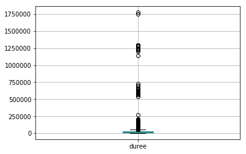

```python
df_ticket.boxplot(column=['duree'])
plt.show()
```

```python
df_ticket.sort_values(by=['duree'] , ascending=False).head(20)
```

|  | id | company | o_station | d_station | departure_ts | arrival_ts | price_in_cents | search_ts | middle_stations | other_companies | o_city | d_city | duree |
| --- | --- | --- | --- | --- | --- | --- | --- | --- | --- | --- | --- | --- | --- |
| 5175 | 6800200 | 8372 | 860.0 | 396.0 | 2017-10-27 23:59:00 | 2017-11-17 12:50:00 | 3200 | 2017-10-02 20:39:10.750 | {10760,10144} | {9} | 126 | 453 | 1774260.0 |
| 5176 | 6800201 | 8372 | 860.0 | 396.0 | 2017-10-27 23:59:00 | 2017-11-17 06:40:00 | 3390 | 2017-10-02 20:39:10.750 | {10760,279} | {13} | 126 | 453 | 1752060.0 |
| 51070 | 6846095 | 8371 | 1044.0 | 10748.0 | 2017-12-22 11:00:00 | 2018-01-06 11:00:00 | 4800 | 2017-10-14 08:27:16.400 | {496,496} | {8372} | 542 | 7507 | 1296000.0 |
| 51069 | 6846094 | 8371 | 1044.0 | 10748.0 | 2017-12-22 11:00:00 | 2018-01-06 11:00:00 | 4800 | 2017-10-14 08:26:09.858 | {496,496} | {8372} | 542 | 7507 | 1296000.0 |
| 47856 | 6842881 | 8371 | 1044.0 | 10748.0 | 2017-12-23 11:00:00 | 2018-01-07 11:00:00 | 4800 | 2017-10-13 07:14:20.422 | {496,496} | {8372} | 542 | 7507 | 1296000.0 |
| 47854 | 6842879 | 8371 | 1044.0 | 10748.0 | 2017-12-23 11:00:00 | 2018-01-07 11:00:00 | 4800 | 2017-10-13 07:11:52.135 | {496,496} | {8372} | 542 | 7507 | 1296000.0 |
| 47858 | 6842883 | 8371 | 1044.0 | 10748.0 | 2017-12-23 11:00:00 | 2018-01-07 11:00:00 | 4800 | 2017-10-13 07:16:01.076 | {496,496} | {8372} | 542 | 7507 | 1296000.0 |
| 51271 | 6846296 | 8371 | 1044.0 | 10748.0 | 2017-12-22 11:00:00 | 2018-01-06 11:00:00 | 4800 | 2017-10-14 09:19:58.996 | {496,496} | {8372} | 542 | 7507 | 1296000.0 |
| 47862 | 6842886 | 8371 | 1044.0 | 10748.0 | 2017-12-23 11:00:00 | 2018-01-07 11:00:00 | 4800 | 2017-10-13 07:16:46.256 | {496,496} | {8372} | 542 | 7507 | 1296000.0 |
| 51053 | 6846078 | 8371 | 1044.0 | 10748.0 | 2017-12-22 11:00:00 | 2018-01-06 11:00:00 | 4800 | 2017-10-14 07:57:16.848 | {496,496} | {8372} | 542 | 7507 | 1296000.0 |
| 51254 | 6846279 | 8371 | 1044.0 | 10748.0 | 2017-12-22 11:00:00 | 2018-01-06 11:00:00 | 4800 | 2017-10-14 09:13:03.686 | {496,496} | {8372} | 542 | 7507 | 1296000.0 |
| 51071 | 6846096 | 8371 | 1044.0 | 10748.0 | 2017-12-22 11:00:00 | 2018-01-06 11:00:00 | 4800 | 2017-10-14 08:28:37.536 | {496,496} | {8372} | 542 | 7507 | 1296000.0 |
| 49232 | 6844257 | 8371 | 1044.0 | 10748.0 | 2017-12-23 11:00:00 | 2018-01-07 11:00:00 | 4800 | 2017-10-13 16:18:39.408 | {496,496} | {8372} | 542 | 7507 | 1296000.0 |
| 51072 | 6846097 | 8371 | 1044.0 | 10748.0 | 2017-12-22 11:00:00 | 2018-01-06 11:00:00 | 4800 | 2017-10-14 08:29:47.346 | {496,496} | {8372} | 542 | 7507 | 1296000.0 |
| 55239 | 6850264 | 8372 | 809.0 | 9985.0 | 2017-10-26 22:00:00 | 2017-11-10 15:00:00 | 11600 | 2017-10-15 13:45:46.857 | {10803,10254} | {13} | 565 | 1918 | 1270800.0 |
| 55250 | 6850275 | 8372 | 809.0 | 9985.0 | 2017-10-26 22:00:00 | 2017-11-10 15:00:00 | 11600 | 2017-10-15 13:50:28.184 | {10803,10254} | {13} | 565 | 1918 | 1270800.0 |
| 55241 | 6850266 | 8372 | 809.0 | 9985.0 | 2017-10-26 22:00:00 | 2017-11-10 15:00:00 | 11600 | 2017-10-15 13:48:31.081 | {10803,10254} | {13} | 565 | 1918 | 1270800.0 |
| 51272 | 6846297 | 8372 | 10707.0 | 1044.0 | 2017-12-20 08:15:00 | 2018-01-03 18:20:00 | 6300 | 2017-10-14 09:20:21.298 | {496,496} | {8371} | 7507 | 542 | 1245900.0 |
| 47857 | 6842882 | 8371 | 1044.0 | 10748.0 | 2017-12-23 11:00:00 | 2018-01-06 20:50:00 | 5300 | 2017-10-13 07:14:20.422 | {496,496} | {8372} | 542 | 7507 | 1245000.0 |
| 47860 | 6842884 | 8371 | 1044.0 | 10748.0 | 2017-12-23 11:00:00 | 2018-01-06 20:50:00 | 5300 | 2017-10-13 07:16:01.077 | {496,496} | {8372} | 542 | 7507 | 1245000.0 |

#### on a trié la colone durée dans l'ordre descendant à fin d'avoir les autres valeurs maximales

```python
from scipy import stats
```

```python
df_ticket[(np.abs(stats.zscore(df_ticket['duree'])) > 3)].sort_values(by=['duree'] , ascending=True)
```

|  | id | company | o_station | d_station | departure_ts | arrival_ts | price_in_cents | search_ts | middle_stations | other_companies | o_city | d_city | duree |
| --- | --- | --- | --- | --- | --- | --- | --- | --- | --- | --- | --- | --- | --- |
| 43256 | 6838280 | 13 | 561.0 | 322.0 | 2017-11-03 11:00:00 | 2017-11-04 23:50:00 | 3980 | 2017-10-12 05:29:24.463 | {455,455} | {13} | 467 | 451 | 132600.0 |
| 54374 | 6849398 | 13 | 586.0 | 581.0 | 2017-10-30 08:00:00 | 2017-10-31 20:50:00 | 4570 | 2017-10-15 10:54:42.523 | {143,143,500,500} | {13,13} | 485 | 424 | 132600.0 |
| 46044 | 6841069 | 9 | 279.0 | 894.0 | 2017-11-01 18:40:00 | 2017-11-03 07:30:00 | 4490 | 2017-10-12 15:35:23.671 | {63,964} | {13} | 628 | 825 | 132600.0 |
| 46094 | 6841119 | 13 | 586.0 | 435.0 | 2017-10-29 21:20:00 | 2017-10-31 10:15:00 | 7690 | 2017-10-12 15:38:58.368 | {257,804} | {13} | 485 | 411 | 132900.0 |
| 46095 | 6841120 | 13 | 586.0 | 435.0 | 2017-10-29 22:15:00 | 2017-10-31 11:10:00 | 7490 | 2017-10-12 15:38:58.369 | {139,139} | {190} | 485 | 411 | 132900.0 |
| 56586 | 6851611 | 13 | 283.0 | 218.0 | 2017-10-21 20:00:00 | 2017-10-23 08:55:00 | 6790 | 2017-10-15 17:09:12.233 | {279,279} | {13} | 1061 | 76 | 132900.0 |
| 43154 | 6838178 | 8371 | 586.0 | 396.0 | 2017-10-20 10:30:00 | 2017-10-21 23:25:00 | 2500 | 2017-10-11 22:31:50.879 | {10642,10144} | {9} | 485 | 453 | 132900.0 |
| 53145 | 6848170 | 13 | 9156.0 | 3594.0 | 2017-12-23 19:40:00 | 2017-12-25 08:40:00 | 5990 | 2017-10-14 16:47:43.736 | {408,408,418,418} | {13,13} | 7168 | 1041 | 133200.0 |
| 58286 | 6853310 | 8377 | 6833.0 | 575.0 | 2017-10-30 09:00:00 | 2017-10-31 22:00:00 | 9980 | 2017-10-16 08:56:08.392 | {4285,4285,3893,3893,4631,4628} | {8380,8380,8380} | 638 | 227 | 133200.0 |
| 58229 | 6853253 | 8377 | 6833.0 | 575.0 | 2017-10-30 09:00:00 | 2017-10-31 22:00:00 | 9980 | 2017-10-16 08:29:10.849 | {4285,4285,3893,3893,4631,4628} | {8380,8380,8380} | 638 | 227 | 133200.0 |
| 58240 | 6853264 | 8377 | 6833.0 | 575.0 | 2017-10-30 09:00:00 | 2017-10-31 22:00:00 | 9980 | 2017-10-16 08:29:49.855 | {4285,4285,3893,3893,4631,4628} | {8380,8380,8380} | 638 | 227 | 133200.0 |
| 58374 | 6853380 | 8377 | 6833.0 | 575.0 | 2017-10-30 09:00:00 | 2017-10-31 22:00:00 | 9980 | 2017-10-16 09:15:25.832 | {4285,4285,3893,3893,4631,4628} | {8380,8380,8380} | 638 | 227 | 133200.0 |
| 58375 | 6853391 | 8377 | 6833.0 | 575.0 | 2017-10-30 09:00:00 | 2017-10-31 22:00:00 | 9980 | 2017-10-16 09:15:45.431 | {4285,4285,3893,3893,4631,4628} | {8380,8380,8380} | 638 | 227 | 133200.0 |
| 58414 | 6853438 | 8377 | 6833.0 | 575.0 | 2017-10-30 09:00:00 | 2017-10-31 22:00:00 | 9980 | 2017-10-16 09:25:46.657 | {4285,4285,3893,3893,4631,4628} | {8380,8380,8380} | 638 | 227 | 133200.0 |
| 58429 | 6853452 | 8377 | 6833.0 | 575.0 | 2017-10-30 09:00:00 | 2017-10-31 22:00:00 | 9980 | 2017-10-16 09:26:51.764 | {4285,4285,3893,3893,4631,4628} | {8380,8380,8380} | 638 | 227 | 133200.0 |
| 58439 | 6853462 | 8377 | 6833.0 | 575.0 | 2017-10-31 09:00:00 | 2017-11-01 22:00:00 | 9980 | 2017-10-16 09:27:18.258 | {4285,4285,3893,3893,4631,4628} | {8380,8380,8380} | 638 | 227 | 133200.0 |
| 63062 | 6858087 | 8372 | 283.0 | 400.0 | 2017-10-20 23:00:00 | 2017-10-22 12:00:00 | 9690 | 2017-10-17 09:51:00.860 | {487,487} | {13} | 451 | 580 | 133200.0 |
| 58211 | 6853236 | 8377 | 6833.0 | 575.0 | 2017-10-30 09:00:00 | 2017-10-31 22:00:00 | 9980 | 2017-10-16 08:26:12.634 | {4285,4285,3893,3893,4631,4628} | {8380,8380,8380} | 638 | 227 | 133200.0 |
| 47473 | 6842501 | 8380 | 6638.0 | 6794.0 | 2017-10-15 19:36:00 | 2017-10-17 08:38:00 | 8350 | 2017-10-12 20:48:27.136 | {7547,7547} | {8381} | 580 | 628 | 133320.0 |
| 60716 | 6855741 | 8376 | 6105.0 | 334.0 | 2017-10-20 10:45:00 | 2017-10-21 23:49:00 | 14450 | 2017-10-16 18:49:51.688 | {6352,6352,4953,4953,86,4049} | {8376,8380,8376} | 9742 | 504 | 133440.0 |
| 39443 | 6834466 | 8380 | 279.0 | 6639.0 | 2017-10-13 09:26:00 | 2017-10-14 22:32:00 | 11600 | 2017-10-11 06:48:15.629 | {747,747} | {8376} | 628 | 580 | 133560.0 |
| 39569 | 6834594 | 8380 | 279.0 | 6639.0 | 2017-10-13 09:26:00 | 2017-10-14 22:32:00 | 11600 | 2017-10-11 07:08:30.729 | {747,747} | {8376} | 628 | 580 | 133560.0 |
| 39577 | 6834602 | 8380 | 279.0 | 6639.0 | 2017-10-13 09:26:00 | 2017-10-14 22:32:00 | 11600 | 2017-10-11 07:08:32.413 | {747,747} | {8376} | 628 | 580 | 133560.0 |
| 37012 | 6832037 | 8380 | 279.0 | 6639.0 | 2017-10-13 09:26:00 | 2017-10-14 22:32:00 | 11600 | 2017-10-10 13:44:47.877 | {747,747} | {8376} | 628 | 580 | 133560.0 |
| 40226 | 6835251 | 8380 | 279.0 | 6639.0 | 2017-10-13 09:26:00 | 2017-10-14 22:32:00 | 11600 | 2017-10-11 09:32:51.802 | {747,747} | {8376} | 628 | 580 | 133560.0 |
| 47460 | 6842485 | 8376 | 6639.0 | 6797.0 | 2017-10-15 09:27:00 | 2017-10-16 22:41:00 | 8100 | 2017-10-12 20:48:27.136 | {5904,5904} | {8376} | 580 | 628 | 134040.0 |
| 45335 | 6840360 | 8372 | 10642.0 | 2464.0 | 2017-10-29 14:30:00 | 2017-10-31 03:45:00 | 4538 | 2017-10-12 13:35:02.870 | {561,561} | {71} | 628 | 2023 | 134100.0 |
| 63842 | 6858867 | 8376 | 6651.0 | 6794.0 | 2017-10-20 09:32:00 | 2017-10-21 22:49:00 | 3750 | 2017-10-17 16:18:15.347 | {7524,7524} | {8376} | 587 | 628 | 134220.0 |
| 40669 | 6835693 | 8376 | 1086.0 | 6560.0 | 2017-10-13 10:11:00 | 2017-10-14 23:29:00 | 15600 | 2017-10-11 10:35:01.333 | {4206,4206,368,368} | {8376,8376} | 840 | 556 | 134280.0 |
| 44527 | 6839551 | 13 | 767.0 | 396.0 | 2017-10-20 05:25:00 | 2017-10-21 18:45:00 | 1800 | 2017-10-12 10:52:35.990 | {932,932} | {13} | 628 | 453 | 134400.0 |
| ... | ... | ... | ... | ... | ... | ... | ... | ... | ... | ... | ... | ... | ... |
| 9074 | 6804099 | 9 | 279.0 | 10818.0 | 2017-10-06 11:15:00 | 2017-10-14 21:00:00 | 8490 | 2017-10-04 09:33:55.092 | {523,523} | {8372} | 628 | 11727 | 726300.0 |
| 42981 | 6838006 | 13 | 273.0 | 509.0 | 2017-10-20 23:00:00 | 2017-11-03 04:45:00 | 2300 | 2017-10-11 21:00:14.636 | {250,250} | {8372} | 23 | 712 | 1143900.0 |
| 51278 | 6846302 | 8372 | 10748.0 | 1044.0 | 2017-12-20 16:20:00 | 2018-01-03 13:40:00 | 9490 | 2017-10-14 09:20:21.299 | {496,496} | {13} | 7507 | 542 | 1200000.0 |
| 51274 | 6846298 | 8372 | 10748.0 | 1044.0 | 2017-12-20 16:20:00 | 2018-01-03 18:20:00 | 8300 | 2017-10-14 09:20:21.299 | {496,496} | {8371} | 7507 | 542 | 1216800.0 |
| 51277 | 6846301 | 8372 | 10748.0 | 1044.0 | 2017-12-20 09:00:00 | 2018-01-03 13:40:00 | 7490 | 2017-10-14 09:20:21.299 | {496,496} | {13} | 7507 | 542 | 1226400.0 |
| 51275 | 6846299 | 8372 | 10707.0 | 1044.0 | 2017-12-20 08:15:00 | 2018-01-03 13:40:00 | 7490 | 2017-10-14 09:20:21.298 | {496,496} | {13} | 7507 | 542 | 1229100.0 |
| 51276 | 6846300 | 8372 | 10748.0 | 1044.0 | 2017-12-20 09:00:00 | 2018-01-03 18:20:00 | 6300 | 2017-10-14 09:20:21.298 | {496,496} | {8371} | 7507 | 542 | 1243200.0 |
| 47855 | 6842880 | 8371 | 1044.0 | 10748.0 | 2017-12-23 11:00:00 | 2018-01-06 20:50:00 | 5300 | 2017-10-13 07:11:52.136 | {496,496} | {8372} | 542 | 7507 | 1245000.0 |
| 49233 | 6844258 | 8371 | 1044.0 | 10748.0 | 2017-12-23 11:00:00 | 2018-01-06 20:50:00 | 5300 | 2017-10-13 16:18:39.408 | {496,496} | {8372} | 542 | 7507 | 1245000.0 |
| 47861 | 6842885 | 8371 | 1044.0 | 10748.0 | 2017-12-23 11:00:00 | 2018-01-06 20:50:00 | 5300 | 2017-10-13 07:16:46.256 | {496,496} | {8372} | 542 | 7507 | 1245000.0 |
| 47860 | 6842884 | 8371 | 1044.0 | 10748.0 | 2017-12-23 11:00:00 | 2018-01-06 20:50:00 | 5300 | 2017-10-13 07:16:01.077 | {496,496} | {8372} | 542 | 7507 | 1245000.0 |
| 47857 | 6842882 | 8371 | 1044.0 | 10748.0 | 2017-12-23 11:00:00 | 2018-01-06 20:50:00 | 5300 | 2017-10-13 07:14:20.422 | {496,496} | {8372} | 542 | 7507 | 1245000.0 |
| 51272 | 6846297 | 8372 | 10707.0 | 1044.0 | 2017-12-20 08:15:00 | 2018-01-03 18:20:00 | 6300 | 2017-10-14 09:20:21.298 | {496,496} | {8371} | 7507 | 542 | 1245900.0 |
| 55250 | 6850275 | 8372 | 809.0 | 9985.0 | 2017-10-26 22:00:00 | 2017-11-10 15:00:00 | 11600 | 2017-10-15 13:50:28.184 | {10803,10254} | {13} | 565 | 1918 | 1270800.0 |
| 55239 | 6850264 | 8372 | 809.0 | 9985.0 | 2017-10-26 22:00:00 | 2017-11-10 15:00:00 | 11600 | 2017-10-15 13:45:46.857 | {10803,10254} | {13} | 565 | 1918 | 1270800.0 |
| 55241 | 6850266 | 8372 | 809.0 | 9985.0 | 2017-10-26 22:00:00 | 2017-11-10 15:00:00 | 11600 | 2017-10-15 13:48:31.081 | {10803,10254} | {13} | 565 | 1918 | 1270800.0 |
| 51069 | 6846094 | 8371 | 1044.0 | 10748.0 | 2017-12-22 11:00:00 | 2018-01-06 11:00:00 | 4800 | 2017-10-14 08:26:09.858 | {496,496} | {8372} | 542 | 7507 | 1296000.0 |
| 51071 | 6846096 | 8371 | 1044.0 | 10748.0 | 2017-12-22 11:00:00 | 2018-01-06 11:00:00 | 4800 | 2017-10-14 08:28:37.536 | {496,496} | {8372} | 542 | 7507 | 1296000.0 |
| 51053 | 6846078 | 8371 | 1044.0 | 10748.0 | 2017-12-22 11:00:00 | 2018-01-06 11:00:00 | 4800 | 2017-10-14 07:57:16.848 | {496,496} | {8372} | 542 | 7507 | 1296000.0 |
| 51072 | 6846097 | 8371 | 1044.0 | 10748.0 | 2017-12-22 11:00:00 | 2018-01-06 11:00:00 | 4800 | 2017-10-14 08:29:47.346 | {496,496} | {8372} | 542 | 7507 | 1296000.0 |
| 51070 | 6846095 | 8371 | 1044.0 | 10748.0 | 2017-12-22 11:00:00 | 2018-01-06 11:00:00 | 4800 | 2017-10-14 08:27:16.400 | {496,496} | {8372} | 542 | 7507 | 1296000.0 |
| 47856 | 6842881 | 8371 | 1044.0 | 10748.0 | 2017-12-23 11:00:00 | 2018-01-07 11:00:00 | 4800 | 2017-10-13 07:14:20.422 | {496,496} | {8372} | 542 | 7507 | 1296000.0 |
| 49232 | 6844257 | 8371 | 1044.0 | 10748.0 | 2017-12-23 11:00:00 | 2018-01-07 11:00:00 | 4800 | 2017-10-13 16:18:39.408 | {496,496} | {8372} | 542 | 7507 | 1296000.0 |
| 51271 | 6846296 | 8371 | 1044.0 | 10748.0 | 2017-12-22 11:00:00 | 2018-01-06 11:00:00 | 4800 | 2017-10-14 09:19:58.996 | {496,496} | {8372} | 542 | 7507 | 1296000.0 |
| 47862 | 6842886 | 8371 | 1044.0 | 10748.0 | 2017-12-23 11:00:00 | 2018-01-07 11:00:00 | 4800 | 2017-10-13 07:16:46.256 | {496,496} | {8372} | 542 | 7507 | 1296000.0 |
| 47858 | 6842883 | 8371 | 1044.0 | 10748.0 | 2017-12-23 11:00:00 | 2018-01-07 11:00:00 | 4800 | 2017-10-13 07:16:01.076 | {496,496} | {8372} | 542 | 7507 | 1296000.0 |
| 47854 | 6842879 | 8371 | 1044.0 | 10748.0 | 2017-12-23 11:00:00 | 2018-01-07 11:00:00 | 4800 | 2017-10-13 07:11:52.135 | {496,496} | {8372} | 542 | 7507 | 1296000.0 |
| 51254 | 6846279 | 8371 | 1044.0 | 10748.0 | 2017-12-22 11:00:00 | 2018-01-06 11:00:00 | 4800 | 2017-10-14 09:13:03.686 | {496,496} | {8372} | 542 | 7507 | 1296000.0 |
| 5176 | 6800201 | 8372 | 860.0 | 396.0 | 2017-10-27 23:59:00 | 2017-11-17 06:40:00 | 3390 | 2017-10-02 20:39:10.750 | {10760,279} | {13} | 126 | 453 | 1752060.0 |
| 5175 | 6800200 | 8372 | 860.0 | 396.0 | 2017-10-27 23:59:00 | 2017-11-17 12:50:00 | 3200 | 2017-10-02 20:39:10.750 | {10760,10144} | {9} | 126 | 453 | 1774260.0 |

335 rows × 13 columns

#### on a trouvé 335 trajet identifés comme outliers

#### on remarque aussi qu'il ya des doublons

```python
df_ticket = df_ticket.drop_duplicates(['company','departure_ts','arrival_ts'])
df_ticket = df_ticket.reset_index(drop=True)
```

```python
df_ticket['duree'].describe()
```

```
count    3.414100e+04
mean     2.963403e+04
std      3.923230e+04
min      1.200000e+03
25%      1.200000e+04
50%      1.938000e+04
75%      3.540000e+04
max      1.774260e+06
Name: duree, dtype: float64
```

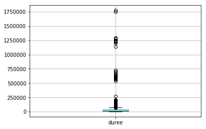

```python
df_ticket.boxplot(column=['duree'])
plt.show()
```

```python
df_ticket[(np.abs(stats.zscore(df_ticket['duree'])) > 3.9)].sort_values(by=['duree'] , ascending=True)
```

|  | id | company | o_station | d_station | departure_ts | arrival_ts | price_in_cents | search_ts | middle_stations | other_companies | o_city | d_city | duree |
| --- | --- | --- | --- | --- | --- | --- | --- | --- | --- | --- | --- | --- | --- |
| 22991 | 6844809 | 8371 | 571.0 | 322.0 | 2017-10-14 01:00:00 | 2017-10-16 04:00:00 | 3100 | 2017-10-13 19:25:29.885 | {523,523} | {13} | 185 | 451 | 183600.0 |
| 33641 | 6868020 | 71 | 3078.0 | 400.0 | 2017-10-20 05:35:00 | 2017-10-22 09:20:00 | 12201 | 2017-10-18 22:53:04.123 | {561,561,279,848} | {13,13} | 2406 | 580 | 186300.0 |
| 3103 | 6800247 | 13 | 3.0 | 416.0 | 2017-10-27 22:10:00 | 2017-10-30 02:05:00 | 4000 | 2017-10-02 20:56:43.335 | {475,475} | {12} | 628 | 99 | 186900.0 |
| 33636 | 6868015 | 8372 | 283.0 | 9985.0 | 2017-10-20 09:30:00 | 2017-10-22 14:00:00 | 12100 | 2017-10-18 22:41:56.752 | {863,863} | {13} | 451 | 1918 | 189000.0 |
| 3101 | 6800245 | 13 | 279.0 | 416.0 | 2017-10-27 21:30:00 | 2017-10-30 02:05:00 | 4000 | 2017-10-02 20:56:43.335 | {475,475} | {12} | 628 | 99 | 189300.0 |
| 17283 | 6833015 | 8372 | 283.0 | 9985.0 | 2017-11-03 08:00:00 | 2017-11-05 14:00:00 | 11500 | 2017-10-10 17:56:18.454 | {964,964} | {13} | 451 | 1918 | 194400.0 |
| 33635 | 6868013 | 8372 | 283.0 | 9985.0 | 2017-10-20 06:00:00 | 2017-10-22 14:00:00 | 10100 | 2017-10-18 22:41:56.751 | {863,863} | {13} | 451 | 1918 | 201600.0 |
| 17280 | 6833012 | 8372 | 283.0 | 9985.0 | 2017-11-03 06:00:00 | 2017-11-05 14:00:00 | 10900 | 2017-10-10 17:56:18.454 | {500,500} | {13} | 451 | 1918 | 201600.0 |
| 1977 | 6797937 | 9 | 279.0 | 9985.0 | 2017-10-06 07:30:00 | 2017-10-08 15:40:00 | 7190 | 2017-10-02 10:10:14.139 | {500,245} | {13} | 628 | 1918 | 202200.0 |
| 17281 | 6833013 | 8372 | 322.0 | 9985.0 | 2017-11-03 07:30:00 | 2017-11-05 15:40:00 | 7790 | 2017-10-10 17:56:18.454 | {10642,279} | {13} | 451 | 1918 | 202200.0 |
| 17279 | 6833011 | 8372 | 283.0 | 9985.0 | 2017-11-03 06:00:00 | 2017-11-05 15:40:00 | 9190 | 2017-10-10 17:56:18.454 | {500,245} | {13} | 451 | 1918 | 207600.0 |
| 17783 | 6834076 | 8372 | 433.0 | 254.0 | 2017-10-18 08:30:00 | 2017-10-21 10:40:00 | 14900 | 2017-10-10 21:24:01.034 | {1187,1187,416,416} | {13,12} | 200 | 1094 | 267000.0 |
| 286 | 6795489 | 8372 | 860.0 | 396.0 | 2017-10-20 23:59:00 | 2017-10-27 06:40:00 | 3990 | 2017-10-01 09:08:05.511 | {10760,279} | {13} | 126 | 453 | 542460.0 |
| 27200 | 6853505 | 8372 | 10642.0 | 1113.0 | 2017-11-10 17:00:00 | 2017-11-17 05:00:00 | 3890 | 2017-10-16 09:48:44.976 | {908,908} | {13} | 628 | 880 | 561600.0 |
| 2374 | 6798756 | 8372 | 10642.0 | 1113.0 | 2017-10-06 17:00:00 | 2017-10-13 05:00:00 | 7990 | 2017-10-02 14:16:13.670 | {908,908} | {13} | 628 | 880 | 561600.0 |
| 285 | 6795488 | 8372 | 860.0 | 396.0 | 2017-10-20 23:59:00 | 2017-10-27 12:50:00 | 3200 | 2017-10-01 09:08:05.511 | {10760,10144} | {9} | 126 | 453 | 564660.0 |
| 843 | 6796214 | 8372 | 10760.0 | 57.0 | 2017-10-06 19:30:00 | 2017-10-13 09:10:00 | 3890 | 2017-10-01 13:13:19.204 | {860,860} | {13} | 628 | 109 | 567600.0 |
| 27199 | 6853504 | 8372 | 10642.0 | 381.0 | 2017-11-10 17:00:00 | 2017-11-17 10:20:00 | 3600 | 2017-10-16 09:48:44.975 | {908,908} | {13} | 628 | 880 | 580800.0 |
| 26204 | 6851720 | 8372 | 10642.0 | 417.0 | 2017-11-10 17:00:00 | 2017-11-17 12:15:00 | 3890 | 2017-10-15 17:18:14.269 | {125,125} | {13} | 628 | 122 | 587700.0 |
| 18322 | 6835374 | 8372 | 10760.0 | 156.0 | 2017-10-13 19:30:00 | 2017-10-20 16:10:00 | 2290 | 2017-10-11 10:01:59.895 | {500,500} | {13} | 628 | 197 | 592800.0 |
| 31463 | 6861969 | 8371 | 496.0 | 571.0 | 2017-12-27 16:00:00 | 2018-01-03 14:30:00 | 3100 | 2017-10-18 09:29:47.820 | {1044,1044} | {8372} | 639 | 185 | 599400.0 |
| 25589 | 6850427 | 8372 | 412.0 | 12.0 | 2017-10-22 08:30:00 | 2017-10-29 07:00:00 | 3690 | 2017-10-15 13:54:14.892 | {589,515} | {13} | 57 | 485 | 599400.0 |
| 842 | 6796213 | 8372 | 10760.0 | 568.0 | 2017-10-06 19:30:00 | 2017-10-13 18:55:00 | 2900 | 2017-10-01 13:13:19.204 | {10638,10638} | {8371} | 628 | 109 | 602700.0 |
| 2373 | 6798755 | 8372 | 10642.0 | 381.0 | 2017-10-06 17:00:00 | 2017-10-13 18:15:00 | 7790 | 2017-10-02 14:16:13.669 | {908,908} | {13} | 628 | 880 | 609300.0 |
| 33471 | 6867312 | 9 | 279.0 | 10731.0 | 2017-12-11 16:00:00 | 2017-12-18 20:15:00 | 5300 | 2017-10-18 21:06:24.032 | {589,589} | {8372} | 628 | 585 | 620100.0 |
| 33470 | 6867311 | 13 | 279.0 | 10731.0 | 2017-12-11 15:15:00 | 2017-12-18 20:15:00 | 5000 | 2017-10-18 21:06:24.032 | {515,589} | {8372} | 628 | 585 | 622800.0 |
| 23469 | 6846098 | 8372 | 10642.0 | 4801.0 | 2017-12-21 18:00:00 | 2017-12-29 00:00:00 | 12800 | 2017-10-14 08:34:14.866 | {10587,9907} | {13} | 628 | 213 | 626400.0 |
| 30878 | 6860926 | 8372 | 876.0 | 1121.0 | 2017-11-01 03:00:00 | 2017-11-08 15:45:00 | 9690 | 2017-10-17 23:22:10.152 | {412,412,482,789} | {8372,13} | 635 | 884 | 650700.0 |
| 19879 | 6838561 | 8372 | 143.0 | 9985.0 | 2017-12-21 23:30:00 | 2017-12-29 14:00:00 | 12600 | 2017-10-12 06:03:11.100 | {10577,9696} | {13} | 152 | 1918 | 657000.0 |
| 29585 | 6858271 | 8372 | 10621.0 | 496.0 | 2017-12-21 13:30:00 | 2017-12-29 04:10:00 | 4590 | 2017-10-17 12:00:15.487 | {526,526} | {13} | 580 | 639 | 657600.0 |
| 26203 | 6851719 | 8372 | 10642.0 | 417.0 | 2017-11-10 17:00:00 | 2017-11-18 12:15:00 | 3600 | 2017-10-15 17:18:14.269 | {125,125} | {13} | 628 | 122 | 674100.0 |
| 2554 | 6799094 | 13 | 9738.0 | 151.0 | 2017-10-03 10:30:00 | 2017-10-11 11:45:00 | 22900 | 2017-10-02 16:30:32.309 | {9696,10577} | {8372} | 6135 | 694 | 695700.0 |
| 17786 | 6834079 | 8372 | 433.0 | 254.0 | 2017-10-20 08:30:00 | 2017-10-28 10:40:00 | 14900 | 2017-10-10 21:24:44.941 | {1187,1187,416,416} | {13,12} | 200 | 1094 | 699000.0 |
| 5005 | 6804099 | 9 | 279.0 | 10818.0 | 2017-10-06 11:15:00 | 2017-10-14 21:00:00 | 8490 | 2017-10-04 09:33:55.092 | {523,523} | {8372} | 628 | 11727 | 726300.0 |
| 19576 | 6838006 | 13 | 273.0 | 509.0 | 2017-10-20 23:00:00 | 2017-11-03 04:45:00 | 2300 | 2017-10-11 21:00:14.636 | {250,250} | {8372} | 23 | 712 | 1143900.0 |
| 23550 | 6846302 | 8372 | 10748.0 | 1044.0 | 2017-12-20 16:20:00 | 2018-01-03 13:40:00 | 9490 | 2017-10-14 09:20:21.299 | {496,496} | {13} | 7507 | 542 | 1200000.0 |
| 23546 | 6846298 | 8372 | 10748.0 | 1044.0 | 2017-12-20 16:20:00 | 2018-01-03 18:20:00 | 8300 | 2017-10-14 09:20:21.299 | {496,496} | {8371} | 7507 | 542 | 1216800.0 |
| 23549 | 6846301 | 8372 | 10748.0 | 1044.0 | 2017-12-20 09:00:00 | 2018-01-03 13:40:00 | 7490 | 2017-10-14 09:20:21.299 | {496,496} | {13} | 7507 | 542 | 1226400.0 |
| 23547 | 6846299 | 8372 | 10707.0 | 1044.0 | 2017-12-20 08:15:00 | 2018-01-03 13:40:00 | 7490 | 2017-10-14 09:20:21.298 | {496,496} | {13} | 7507 | 542 | 1229100.0 |
| 23548 | 6846300 | 8372 | 10748.0 | 1044.0 | 2017-12-20 09:00:00 | 2018-01-03 18:20:00 | 6300 | 2017-10-14 09:20:21.298 | {496,496} | {8371} | 7507 | 542 | 1243200.0 |
| 22003 | 6842880 | 8371 | 1044.0 | 10748.0 | 2017-12-23 11:00:00 | 2018-01-06 20:50:00 | 5300 | 2017-10-13 07:11:52.136 | {496,496} | {8372} | 542 | 7507 | 1245000.0 |
| 23545 | 6846297 | 8372 | 10707.0 | 1044.0 | 2017-12-20 08:15:00 | 2018-01-03 18:20:00 | 6300 | 2017-10-14 09:20:21.298 | {496,496} | {8371} | 7507 | 542 | 1245900.0 |
| 25445 | 6850264 | 8372 | 809.0 | 9985.0 | 2017-10-26 22:00:00 | 2017-11-10 15:00:00 | 11600 | 2017-10-15 13:45:46.857 | {10803,10254} | {13} | 565 | 1918 | 1270800.0 |
| 23468 | 6846078 | 8371 | 1044.0 | 10748.0 | 2017-12-22 11:00:00 | 2018-01-06 11:00:00 | 4800 | 2017-10-14 07:57:16.848 | {496,496} | {8372} | 542 | 7507 | 1296000.0 |
| 22002 | 6842879 | 8371 | 1044.0 | 10748.0 | 2017-12-23 11:00:00 | 2018-01-07 11:00:00 | 4800 | 2017-10-13 07:11:52.135 | {496,496} | {8372} | 542 | 7507 | 1296000.0 |
| 3057 | 6800201 | 8372 | 860.0 | 396.0 | 2017-10-27 23:59:00 | 2017-11-17 06:40:00 | 3390 | 2017-10-02 20:39:10.750 | {10760,279} | {13} | 126 | 453 | 1752060.0 |
| 3056 | 6800200 | 8372 | 860.0 | 396.0 | 2017-10-27 23:59:00 | 2017-11-17 12:50:00 | 3200 | 2017-10-02 20:39:10.750 | {10760,10144} | {9} | 126 | 453 | 1774260.0 |

```python
df_ticket['duree'].describe()
```

```
count    3.414100e+04
mean     2.963403e+04
std      3.923230e+04
min      1.200000e+03
25%      1.200000e+04
50%      1.938000e+04
75%      3.540000e+04
max      1.774260e+06
Name: duree, dtype: float64
```

```python
df_ticket.loc[df_ticket['duree'] == 183600.0 ]
```

|  | id | company | o_station | d_station | departure_ts | arrival_ts | price_in_cents | search_ts | middle_stations | other_companies | o_city | d_city | duree |
| --- | --- | --- | --- | --- | --- | --- | --- | --- | --- | --- | --- | --- | --- |
| 22991 | 6844809 | 8371 | 571.0 | 322.0 | 2017-10-14 01:00:00 | 2017-10-16 04:00:00 | 3100 | 2017-10-13 19:25:29.885 | {523,523} | {13} | 185 | 451 | 183600.0 |

```python
df_cities.loc[df_cities['id'] == 185]
```

|  | id | local_name | unique_name | latitude | longitude | population |
| --- | --- | --- | --- | --- | --- | --- |
| 5110 | 185 | Chalon-sur-Saône, Bourgogne-Franche-Comté, France | chalon-sur-saone | 46.782719 | 4.845878 | NaN |

```python
df_cities.loc[df_cities['id'] == 451]
```

|  | id | local_name | unique_name | latitude | longitude | population |
| --- | --- | --- | --- | --- | --- | --- |
| 529 | 451 | Liège, Wallonie, Belgique | liege | 50.632557 | 5.579666 | 195931.0 |

```python
df_providers.loc[df_providers['id'] == 8371 ]
```

|  | id | company_id | provider_id | name | fullname | has_wifi | has_plug | has_adjustable_seats | has_bicycle | transport_type |
| --- | --- | --- | --- | --- | --- | --- | --- | --- | --- | --- |
| 209 | 8371 | 20 | I | isilines | Isilines | True | True | True | False | bus |

### transport_type

```python
df_transport_type = df_providers[['id','transport_type']]
df_transport_type.drop_duplicates(['id']).reset_index(drop=True)
```

|  | id | transport_type |
| --- | --- | --- |
| 0 | 9 | bus |
| 1 | 10 | bus |
| 2 | 11 | bus |
| 3 | 12 | bus |
| 4 | 13 | bus |
| 5 | 14 | car |
| 6 | 15 | bus |
| 7 | 16 | bus |
| 8 | 17 | bus |
| 9 | 18 | bus |
| 10 | 19 | bus |
| 11 | 20 | bus |
| 12 | 21 | bus |
| 13 | 22 | bus |
| 14 | 23 | bus |
| 15 | 24 | bus |
| 16 | 25 | bus |
| 17 | 26 | bus |
| 18 | 27 | bus |
| 19 | 28 | bus |
| 20 | 29 | bus |
| 21 | 30 | bus |
| 22 | 31 | bus |
| 23 | 32 | bus |
| 24 | 33 | bus |
| 25 | 34 | bus |
| 26 | 35 | bus |
| 27 | 36 | bus |
| 28 | 37 | bus |
| 29 | 38 | bus |
| ... | ... | ... |
| 197 | 211 | bus |
| 198 | 212 | bus |
| 199 | 214 | bus |
| 200 | 215 | bus |
| 201 | 216 | bus |
| 202 | 217 | bus |
| 203 | 218 | bus |
| 204 | 219 | bus |
| 205 | 220 | bus |
| 206 | 221 | bus |
| 207 | 222 | bus |
| 208 | 4511 | train |
| 209 | 8371 | bus |
| 210 | 8372 | bus |
| 211 | 8373 | bus |
| 212 | 8374 | bus |
| 213 | 8375 | train |
| 214 | 8376 | train |
| 215 | 8377 | train |
| 216 | 8378 | train |
| 217 | 8379 | bus |
| 218 | 8380 | train |
| 219 | 8381 | train |
| 220 | 8382 | train |
| 221 | 8383 | train |
| 222 | 8384 | train |
| 223 | 8385 | carpooling |
| 224 | 8387 | bus |
| 225 | 8388 | bus |
| 226 | 8389 | carpooling |

227 rows × 2 columns

```python
df_ticket = pd.merge(df_ticket,df_transport_type, left_on ='company',right_on='id',how='left')
df_ticket
```

|  | id_x | company | o_station | d_station | departure_ts | arrival_ts | price_in_cents | search_ts | middle_stations | other_companies | o_city | d_city | duree | id_y | transport_type |
| --- | --- | --- | --- | --- | --- | --- | --- | --- | --- | --- | --- | --- | --- | --- | --- |
| 0 | 6795025 | 8385 | NaN | NaN | 2017-10-13 14:00:00 | 2017-10-13 20:10:00 | 4550 | 2017-10-01 00:13:31.327 | NaN | NaN | 611 | 542 | 22200.0 | 8385 | carpooling |
| 1 | 6795026 | 9 | 63.0 | 1044.0 | 2017-10-13 13:05:00 | 2017-10-14 06:55:00 | 1450 | 2017-10-01 00:13:35.773 | {149,418} | {13} | 611 | 542 | 64200.0 | 9 | bus |
| 2 | 6795027 | 8377 | 5905.0 | 6495.0 | 2017-10-13 13:27:00 | 2017-10-14 21:24:00 | 7400 | 2017-10-01 00:13:40.212 | {798,798,6794,6246} | {8377,8376} | 611 | 542 | 115020.0 | 8377 | train |
| 3 | 6795028 | 8377 | 5905.0 | 6495.0 | 2017-10-13 13:27:00 | 2017-10-14 11:02:00 | 13500 | 2017-10-01 00:13:40.213 | {798,798,6794,6246} | {8377,8376} | 611 | 542 | 77700.0 | 8377 | train |
| 4 | 6795029 | 8381 | 5905.0 | 6495.0 | 2017-10-13 21:46:00 | 2017-10-14 19:32:00 | 7710 | 2017-10-01 00:13:40.213 | {5983,5983} | {8380} | 611 | 542 | 78360.0 | 8381 | train |
| 5 | 6795030 | 8385 | NaN | NaN | 2017-10-06 05:30:00 | 2017-10-06 08:30:00 | 1800 | 2017-10-01 01:03:18.948 | NaN | NaN | 628 | 453 | 10800.0 | 8385 | carpooling |
| 6 | 6795031 | 8385 | NaN | NaN | 2017-10-06 07:00:42 | 2017-10-06 09:30:42 | 2150 | 2017-10-01 01:03:18.948 | NaN | NaN | 628 | 453 | 9000.0 | 8385 | carpooling |
| 7 | 6795032 | 8385 | NaN | NaN | 2017-10-06 07:10:00 | 2017-10-06 09:40:00 | 1700 | 2017-10-01 01:03:18.948 | NaN | NaN | 628 | 453 | 9000.0 | 8385 | carpooling |
| 8 | 6795033 | 8385 | NaN | NaN | 2017-10-06 10:00:00 | 2017-10-06 12:50:00 | 1700 | 2017-10-01 01:03:18.948 | NaN | NaN | 628 | 453 | 10200.0 | 8385 | carpooling |
| 9 | 6795035 | 8385 | NaN | NaN | 2017-10-06 12:40:00 | 2017-10-06 15:40:00 | 1550 | 2017-10-01 01:03:18.948 | NaN | NaN | 628 | 453 | 10800.0 | 8385 | carpooling |
| 10 | 6795036 | 8385 | NaN | NaN | 2017-10-06 13:00:00 | 2017-10-06 15:40:00 | 1450 | 2017-10-01 01:03:18.948 | NaN | NaN | 628 | 453 | 9600.0 | 8385 | carpooling |
| 11 | 6795037 | 8385 | NaN | NaN | 2017-10-06 13:00:00 | 2017-10-06 15:30:00 | 1550 | 2017-10-01 01:03:18.948 | NaN | NaN | 628 | 453 | 9000.0 | 8385 | carpooling |
| 12 | 6795040 | 8385 | NaN | NaN | 2017-10-06 13:40:00 | 2017-10-06 16:30:00 | 1700 | 2017-10-01 01:03:18.950 | NaN | NaN | 628 | 453 | 10200.0 | 8385 | carpooling |
| 13 | 6795041 | 8385 | NaN | NaN | 2017-10-06 14:00:16 | 2017-10-06 16:30:16 | 1700 | 2017-10-01 01:03:18.950 | NaN | NaN | 628 | 453 | 9000.0 | 8385 | carpooling |
| 14 | 6795042 | 8385 | NaN | NaN | 2017-10-06 14:00:00 | 2017-10-06 17:00:00 | 1800 | 2017-10-01 01:03:18.950 | NaN | NaN | 628 | 453 | 10800.0 | 8385 | carpooling |
| 15 | 6795043 | 8385 | NaN | NaN | 2017-10-06 14:00:00 | 2017-10-06 17:20:00 | 1900 | 2017-10-01 01:03:18.950 | NaN | NaN | 628 | 453 | 12000.0 | 8385 | carpooling |
| 16 | 6795044 | 8385 | NaN | NaN | 2017-10-06 14:00:00 | 2017-10-06 16:40:00 | 2300 | 2017-10-01 01:03:18.950 | NaN | NaN | 628 | 453 | 9600.0 | 8385 | carpooling |
| 17 | 6795045 | 8385 | NaN | NaN | 2017-10-06 14:50:00 | 2017-10-06 17:40:00 | 1700 | 2017-10-01 01:03:18.950 | NaN | NaN | 628 | 453 | 10200.0 | 8385 | carpooling |
| 18 | 6795046 | 8385 | NaN | NaN | 2017-10-06 15:10:00 | 2017-10-06 17:50:00 | 1800 | 2017-10-01 01:03:18.950 | NaN | NaN | 628 | 453 | 9600.0 | 8385 | carpooling |
| 19 | 6795047 | 8385 | NaN | NaN | 2017-10-06 15:30:00 | 2017-10-06 17:50:00 | 1450 | 2017-10-01 01:03:18.950 | NaN | NaN | 628 | 453 | 8400.0 | 8385 | carpooling |
| 20 | 6795048 | 8385 | NaN | NaN | 2017-10-06 15:50:00 | 2017-10-06 18:50:00 | 1700 | 2017-10-01 01:03:18.950 | NaN | NaN | 628 | 453 | 10800.0 | 8385 | carpooling |
| 21 | 6795050 | 8385 | NaN | NaN | 2017-10-06 16:00:00 | 2017-10-06 19:00:00 | 1700 | 2017-10-01 01:03:18.950 | NaN | NaN | 628 | 453 | 10800.0 | 8385 | carpooling |
| 22 | 6795052 | 8385 | NaN | NaN | 2017-10-06 16:00:00 | 2017-10-06 18:50:00 | 1800 | 2017-10-01 01:03:18.951 | NaN | NaN | 628 | 453 | 10200.0 | 8385 | carpooling |
| 23 | 6795053 | 8385 | NaN | NaN | 2017-10-06 16:50:00 | 2017-10-06 19:20:00 | 1550 | 2017-10-01 01:03:18.951 | NaN | NaN | 628 | 453 | 9000.0 | 8385 | carpooling |
| 24 | 6795054 | 8385 | NaN | NaN | 2017-10-06 17:00:00 | 2017-10-06 19:30:00 | 1300 | 2017-10-01 01:03:18.951 | NaN | NaN | 628 | 453 | 9000.0 | 8385 | carpooling |
| 25 | 6795057 | 8385 | NaN | NaN | 2017-10-06 17:30:00 | 2017-10-06 20:00:00 | 1550 | 2017-10-01 01:03:18.951 | NaN | NaN | 628 | 453 | 9000.0 | 8385 | carpooling |
| 26 | 6795058 | 8385 | NaN | NaN | 2017-10-06 18:00:00 | 2017-10-06 20:30:00 | 1450 | 2017-10-01 01:03:18.951 | NaN | NaN | 628 | 453 | 9000.0 | 8385 | carpooling |
| 27 | 6795059 | 8385 | NaN | NaN | 2017-10-06 18:00:00 | 2017-10-06 20:50:00 | 1700 | 2017-10-01 01:03:18.951 | NaN | NaN | 628 | 453 | 10200.0 | 8385 | carpooling |
| 28 | 6795060 | 8385 | NaN | NaN | 2017-10-06 18:00:00 | 2017-10-06 21:30:00 | 1800 | 2017-10-01 01:03:18.951 | NaN | NaN | 628 | 453 | 12600.0 | 8385 | carpooling |
| 29 | 6795061 | 8385 | NaN | NaN | 2017-10-06 18:00:00 | 2017-10-06 21:00:00 | 1800 | 2017-10-01 01:03:18.951 | NaN | NaN | 628 | 453 | 10800.0 | 8385 | carpooling |
| ... | ... | ... | ... | ... | ... | ... | ... | ... | ... | ... | ... | ... | ... | ... | ... |
| 34111 | 6869134 | 8385 | NaN | NaN | 2017-10-27 13:30:00 | 2017-10-27 17:20:00 | 2900 | 2017-10-19 10:35:31.267 | NaN | NaN | 628 | 562 | 13800.0 | 8385 | carpooling |
| 34112 | 6869135 | 8385 | NaN | NaN | 2017-10-27 13:40:00 | 2017-10-27 17:40:00 | 3350 | 2017-10-19 10:35:31.267 | NaN | NaN | 628 | 562 | 14400.0 | 8385 | carpooling |
| 34113 | 6869136 | 8385 | NaN | NaN | 2017-10-27 14:50:00 | 2017-10-27 19:00:00 | 2750 | 2017-10-19 10:35:31.268 | NaN | NaN | 628 | 562 | 15000.0 | 8385 | carpooling |
| 34114 | 6869140 | 8385 | NaN | NaN | 2017-10-27 15:00:00 | 2017-10-27 19:40:00 | 3100 | 2017-10-19 10:35:31.268 | NaN | NaN | 628 | 562 | 16800.0 | 8385 | carpooling |
| 34115 | 6869141 | 8385 | NaN | NaN | 2017-10-27 15:30:00 | 2017-10-27 19:10:00 | 2750 | 2017-10-19 10:35:31.268 | NaN | NaN | 628 | 562 | 13200.0 | 8385 | carpooling |
| 34116 | 6869143 | 8385 | NaN | NaN | 2017-10-27 15:30:00 | 2017-10-27 20:30:00 | 3000 | 2017-10-19 10:35:31.268 | NaN | NaN | 628 | 562 | 18000.0 | 8385 | carpooling |
| 34117 | 6869146 | 8385 | NaN | NaN | 2017-10-27 15:30:00 | 2017-10-27 19:50:00 | 3700 | 2017-10-19 10:35:31.268 | NaN | NaN | 628 | 562 | 15600.0 | 8385 | carpooling |
| 34118 | 6869148 | 8385 | NaN | NaN | 2017-10-27 16:00:00 | 2017-10-27 19:40:00 | 2650 | 2017-10-19 10:35:31.268 | NaN | NaN | 628 | 562 | 13200.0 | 8385 | carpooling |
| 34119 | 6869149 | 8385 | NaN | NaN | 2017-10-27 16:00:00 | 2017-10-27 20:00:00 | 2650 | 2017-10-19 10:35:31.268 | NaN | NaN | 628 | 562 | 14400.0 | 8385 | carpooling |
| 34120 | 6869150 | 8385 | NaN | NaN | 2017-10-27 16:00:00 | 2017-10-27 21:30:00 | 3000 | 2017-10-19 10:35:31.268 | NaN | NaN | 628 | 562 | 19800.0 | 8385 | carpooling |
| 34121 | 6869152 | 8385 | NaN | NaN | 2017-10-27 16:10:00 | 2017-10-27 20:20:00 | 3000 | 2017-10-19 10:35:31.268 | NaN | NaN | 628 | 562 | 15000.0 | 8385 | carpooling |
| 34122 | 6869153 | 8385 | NaN | NaN | 2017-10-27 16:20:00 | 2017-10-27 20:20:00 | 2900 | 2017-10-19 10:35:31.268 | NaN | NaN | 628 | 562 | 14400.0 | 8385 | carpooling |
| 34123 | 6869154 | 8385 | NaN | NaN | 2017-10-27 16:30:00 | 2017-10-27 20:30:00 | 2500 | 2017-10-19 10:35:31.268 | NaN | NaN | 628 | 562 | 14400.0 | 8385 | carpooling |
| 34124 | 6869155 | 8385 | NaN | NaN | 2017-10-27 16:30:00 | 2017-10-27 20:10:00 | 2750 | 2017-10-19 10:35:31.268 | NaN | NaN | 628 | 562 | 13200.0 | 8385 | carpooling |
| 34125 | 6869156 | 8385 | NaN | NaN | 2017-10-27 16:50:00 | 2017-10-27 22:10:00 | 3350 | 2017-10-19 10:35:31.268 | NaN | NaN | 628 | 562 | 19200.0 | 8385 | carpooling |
| 34126 | 6869164 | 8385 | NaN | NaN | 2017-10-27 18:30:00 | 2017-10-27 22:30:00 | 2900 | 2017-10-19 10:35:31.269 | NaN | NaN | 628 | 562 | 14400.0 | 8385 | carpooling |
| 34127 | 6869166 | 8385 | NaN | NaN | 2017-10-27 18:30:00 | 2017-10-27 23:10:00 | 3000 | 2017-10-19 10:35:31.269 | NaN | NaN | 628 | 562 | 16800.0 | 8385 | carpooling |
| 34128 | 6869167 | 8385 | NaN | NaN | 2017-10-27 19:10:00 | 2017-10-27 23:00:00 | 2650 | 2017-10-19 10:35:31.269 | NaN | NaN | 628 | 562 | 13800.0 | 8385 | carpooling |
| 34129 | 6869168 | 8385 | NaN | NaN | 2017-10-27 21:20:00 | 2017-10-28 01:10:00 | 2900 | 2017-10-19 10:35:31.269 | NaN | NaN | 628 | 562 | 13800.0 | 8385 | carpooling |
| 34130 | 6869169 | 8385 | NaN | NaN | 2017-10-27 21:50:00 | 2017-10-28 01:40:00 | 3600 | 2017-10-19 10:35:31.269 | NaN | NaN | 628 | 562 | 13800.0 | 8385 | carpooling |
| 34131 | 6869170 | 8376 | 767.0 | 6591.0 | 2017-10-27 06:38:00 | 2017-10-27 23:02:00 | 1950 | 2017-10-19 10:35:40.167 | {408,408} | {8377} | 628 | 562 | 59040.0 | 8376 | train |
| 34132 | 6869180 | 8376 | 6799.0 | 6591.0 | 2017-10-27 21:46:00 | 2017-10-28 23:02:00 | 8450 | 2017-10-19 10:35:40.168 | {408,408} | {8377} | 628 | 562 | 90960.0 | 8376 | train |
| 34133 | 6869178 | 8376 | 6799.0 | 6591.0 | 2017-10-27 19:40:00 | 2017-10-28 08:30:00 | 8450 | 2017-10-19 10:35:40.168 | {3748,3748} | {8380} | 628 | 562 | 46200.0 | 8376 | train |
| 34134 | 6869173 | 8376 | 6799.0 | 6591.0 | 2017-10-27 10:40:00 | 2017-10-27 14:50:00 | 7850 | 2017-10-19 10:35:40.168 | {408,408} | {8376} | 628 | 562 | 15000.0 | 8376 | train |
| 34135 | 6869181 | 13 | 3.0 | 10729.0 | 2017-10-27 01:40:00 | 2017-10-27 16:00:00 | 2590 | 2017-10-19 10:35:42.942 | {408,408} | {8371} | 628 | 562 | 51600.0 | 13 | bus |
| 34136 | 6869183 | 8371 | 10642.0 | 304.0 | 2017-10-27 07:00:00 | 2017-10-27 21:10:00 | 2090 | 2017-10-19 10:35:42.943 | {863,863} | {13} | 628 | 562 | 51000.0 | 8371 | bus |
| 34137 | 6869184 | 9 | 279.0 | 10729.0 | 2017-10-27 07:00:00 | 2017-10-27 16:00:00 | 2400 | 2017-10-19 10:35:42.943 | {1105,1105} | {8371} | 628 | 562 | 32400.0 | 9 | bus |
| 34138 | 6869188 | 8371 | 10642.0 | 304.0 | 2017-10-27 10:00:00 | 2017-10-27 22:45:00 | 2100 | 2017-10-19 10:35:42.943 | {1105,1105} | {9} | 628 | 562 | 45900.0 | 8371 | bus |
| 34139 | 6869192 | 13 | 279.0 | 304.0 | 2017-10-27 19:55:00 | 2017-10-28 08:00:00 | 4480 | 2017-10-19 10:35:42.943 | {863,863} | {13} | 628 | 562 | 43500.0 | 13 | bus |
| 34140 | 6869182 | 13 | 279.0 | 10729.0 | 2017-10-27 02:30:00 | 2017-10-27 16:00:00 | 2590 | 2017-10-19 10:35:42.943 | {408,408} | {8371} | 628 | 562 | 48600.0 | 13 | bus |

34141 rows × 15 columns

```python
df_ticket.drop('id_y', axis=1, inplace=True)
```

##### on a fait une fusion entre les dataframes ticket et providers dont la quelle on a pris seullement les id et les type de transport

### origin city

```python
df_cities_ll = df_cities[['id','latitude','longitude']]
df_cities_ll = df_cities_ll.drop_duplicates(['id'])
```

```python
df_origin_city = pd.merge(df_ticket,df_cities_ll, left_on ='o_city',right_on='id',how='left')
# df_origin_city
```

```python
df_origin_city = df_origin_city.rename(columns={"latitude": "o_latitude", "longitude": "o_longitude"})
df_origin_city
```

|  | id_x | company | o_station | d_station | departure_ts | arrival_ts | price_in_cents | search_ts | middle_stations | other_companies | o_city | d_city | duree | transport_type | id | o_latitude | o_longitude |
| --- | --- | --- | --- | --- | --- | --- | --- | --- | --- | --- | --- | --- | --- | --- | --- | --- | --- |
| 0 | 6795025 | 8385 | NaN | NaN | 2017-10-13 14:00:00 | 2017-10-13 20:10:00 | 4550 | 2017-10-01 00:13:31.327 | NaN | NaN | 611 | 542 | 22200.0 | carpooling | 611 | 47.907018 | 1.906270 |
| 1 | 6795026 | 9 | 63.0 | 1044.0 | 2017-10-13 13:05:00 | 2017-10-14 06:55:00 | 1450 | 2017-10-01 00:13:35.773 | {149,418} | {13} | 611 | 542 | 64200.0 | bus | 611 | 47.907018 | 1.906270 |
| 2 | 6795027 | 8377 | 5905.0 | 6495.0 | 2017-10-13 13:27:00 | 2017-10-14 21:24:00 | 7400 | 2017-10-01 00:13:40.212 | {798,798,6794,6246} | {8377,8376} | 611 | 542 | 115020.0 | train | 611 | 47.907018 | 1.906270 |
| 3 | 6795028 | 8377 | 5905.0 | 6495.0 | 2017-10-13 13:27:00 | 2017-10-14 11:02:00 | 13500 | 2017-10-01 00:13:40.213 | {798,798,6794,6246} | {8377,8376} | 611 | 542 | 77700.0 | train | 611 | 47.907018 | 1.906270 |
| 4 | 6795029 | 8381 | 5905.0 | 6495.0 | 2017-10-13 21:46:00 | 2017-10-14 19:32:00 | 7710 | 2017-10-01 00:13:40.213 | {5983,5983} | {8380} | 611 | 542 | 78360.0 | train | 611 | 47.907018 | 1.906270 |
| 5 | 6795030 | 8385 | NaN | NaN | 2017-10-06 05:30:00 | 2017-10-06 08:30:00 | 1800 | 2017-10-01 01:03:18.948 | NaN | NaN | 628 | 453 | 10800.0 | carpooling | 628 | 48.847702 | 2.352311 |
| 6 | 6795031 | 8385 | NaN | NaN | 2017-10-06 07:00:42 | 2017-10-06 09:30:42 | 2150 | 2017-10-01 01:03:18.948 | NaN | NaN | 628 | 453 | 9000.0 | carpooling | 628 | 48.847702 | 2.352311 |
| 7 | 6795032 | 8385 | NaN | NaN | 2017-10-06 07:10:00 | 2017-10-06 09:40:00 | 1700 | 2017-10-01 01:03:18.948 | NaN | NaN | 628 | 453 | 9000.0 | carpooling | 628 | 48.847702 | 2.352311 |
| 8 | 6795033 | 8385 | NaN | NaN | 2017-10-06 10:00:00 | 2017-10-06 12:50:00 | 1700 | 2017-10-01 01:03:18.948 | NaN | NaN | 628 | 453 | 10200.0 | carpooling | 628 | 48.847702 | 2.352311 |
| 9 | 6795035 | 8385 | NaN | NaN | 2017-10-06 12:40:00 | 2017-10-06 15:40:00 | 1550 | 2017-10-01 01:03:18.948 | NaN | NaN | 628 | 453 | 10800.0 | carpooling | 628 | 48.847702 | 2.352311 |
| 10 | 6795036 | 8385 | NaN | NaN | 2017-10-06 13:00:00 | 2017-10-06 15:40:00 | 1450 | 2017-10-01 01:03:18.948 | NaN | NaN | 628 | 453 | 9600.0 | carpooling | 628 | 48.847702 | 2.352311 |
| 11 | 6795037 | 8385 | NaN | NaN | 2017-10-06 13:00:00 | 2017-10-06 15:30:00 | 1550 | 2017-10-01 01:03:18.948 | NaN | NaN | 628 | 453 | 9000.0 | carpooling | 628 | 48.847702 | 2.352311 |
| 12 | 6795040 | 8385 | NaN | NaN | 2017-10-06 13:40:00 | 2017-10-06 16:30:00 | 1700 | 2017-10-01 01:03:18.950 | NaN | NaN | 628 | 453 | 10200.0 | carpooling | 628 | 48.847702 | 2.352311 |
| 13 | 6795041 | 8385 | NaN | NaN | 2017-10-06 14:00:16 | 2017-10-06 16:30:16 | 1700 | 2017-10-01 01:03:18.950 | NaN | NaN | 628 | 453 | 9000.0 | carpooling | 628 | 48.847702 | 2.352311 |
| 14 | 6795042 | 8385 | NaN | NaN | 2017-10-06 14:00:00 | 2017-10-06 17:00:00 | 1800 | 2017-10-01 01:03:18.950 | NaN | NaN | 628 | 453 | 10800.0 | carpooling | 628 | 48.847702 | 2.352311 |
| 15 | 6795043 | 8385 | NaN | NaN | 2017-10-06 14:00:00 | 2017-10-06 17:20:00 | 1900 | 2017-10-01 01:03:18.950 | NaN | NaN | 628 | 453 | 12000.0 | carpooling | 628 | 48.847702 | 2.352311 |
| 16 | 6795044 | 8385 | NaN | NaN | 2017-10-06 14:00:00 | 2017-10-06 16:40:00 | 2300 | 2017-10-01 01:03:18.950 | NaN | NaN | 628 | 453 | 9600.0 | carpooling | 628 | 48.847702 | 2.352311 |
| 17 | 6795045 | 8385 | NaN | NaN | 2017-10-06 14:50:00 | 2017-10-06 17:40:00 | 1700 | 2017-10-01 01:03:18.950 | NaN | NaN | 628 | 453 | 10200.0 | carpooling | 628 | 48.847702 | 2.352311 |
| 18 | 6795046 | 8385 | NaN | NaN | 2017-10-06 15:10:00 | 2017-10-06 17:50:00 | 1800 | 2017-10-01 01:03:18.950 | NaN | NaN | 628 | 453 | 9600.0 | carpooling | 628 | 48.847702 | 2.352311 |
| 19 | 6795047 | 8385 | NaN | NaN | 2017-10-06 15:30:00 | 2017-10-06 17:50:00 | 1450 | 2017-10-01 01:03:18.950 | NaN | NaN | 628 | 453 | 8400.0 | carpooling | 628 | 48.847702 | 2.352311 |
| 20 | 6795048 | 8385 | NaN | NaN | 2017-10-06 15:50:00 | 2017-10-06 18:50:00 | 1700 | 2017-10-01 01:03:18.950 | NaN | NaN | 628 | 453 | 10800.0 | carpooling | 628 | 48.847702 | 2.352311 |
| 21 | 6795050 | 8385 | NaN | NaN | 2017-10-06 16:00:00 | 2017-10-06 19:00:00 | 1700 | 2017-10-01 01:03:18.950 | NaN | NaN | 628 | 453 | 10800.0 | carpooling | 628 | 48.847702 | 2.352311 |
| 22 | 6795052 | 8385 | NaN | NaN | 2017-10-06 16:00:00 | 2017-10-06 18:50:00 | 1800 | 2017-10-01 01:03:18.951 | NaN | NaN | 628 | 453 | 10200.0 | carpooling | 628 | 48.847702 | 2.352311 |
| 23 | 6795053 | 8385 | NaN | NaN | 2017-10-06 16:50:00 | 2017-10-06 19:20:00 | 1550 | 2017-10-01 01:03:18.951 | NaN | NaN | 628 | 453 | 9000.0 | carpooling | 628 | 48.847702 | 2.352311 |
| 24 | 6795054 | 8385 | NaN | NaN | 2017-10-06 17:00:00 | 2017-10-06 19:30:00 | 1300 | 2017-10-01 01:03:18.951 | NaN | NaN | 628 | 453 | 9000.0 | carpooling | 628 | 48.847702 | 2.352311 |
| 25 | 6795057 | 8385 | NaN | NaN | 2017-10-06 17:30:00 | 2017-10-06 20:00:00 | 1550 | 2017-10-01 01:03:18.951 | NaN | NaN | 628 | 453 | 9000.0 | carpooling | 628 | 48.847702 | 2.352311 |
| 26 | 6795058 | 8385 | NaN | NaN | 2017-10-06 18:00:00 | 2017-10-06 20:30:00 | 1450 | 2017-10-01 01:03:18.951 | NaN | NaN | 628 | 453 | 9000.0 | carpooling | 628 | 48.847702 | 2.352311 |
| 27 | 6795059 | 8385 | NaN | NaN | 2017-10-06 18:00:00 | 2017-10-06 20:50:00 | 1700 | 2017-10-01 01:03:18.951 | NaN | NaN | 628 | 453 | 10200.0 | carpooling | 628 | 48.847702 | 2.352311 |
| 28 | 6795060 | 8385 | NaN | NaN | 2017-10-06 18:00:00 | 2017-10-06 21:30:00 | 1800 | 2017-10-01 01:03:18.951 | NaN | NaN | 628 | 453 | 12600.0 | carpooling | 628 | 48.847702 | 2.352311 |
| 29 | 6795061 | 8385 | NaN | NaN | 2017-10-06 18:00:00 | 2017-10-06 21:00:00 | 1800 | 2017-10-01 01:03:18.951 | NaN | NaN | 628 | 453 | 10800.0 | carpooling | 628 | 48.847702 | 2.352311 |
| ... | ... | ... | ... | ... | ... | ... | ... | ... | ... | ... | ... | ... | ... | ... | ... | ... | ... |
| 34111 | 6869134 | 8385 | NaN | NaN | 2017-10-27 13:30:00 | 2017-10-27 17:20:00 | 2900 | 2017-10-19 10:35:31.267 | NaN | NaN | 628 | 562 | 13800.0 | carpooling | 628 | 48.847702 | 2.352311 |
| 34112 | 6869135 | 8385 | NaN | NaN | 2017-10-27 13:40:00 | 2017-10-27 17:40:00 | 3350 | 2017-10-19 10:35:31.267 | NaN | NaN | 628 | 562 | 14400.0 | carpooling | 628 | 48.847702 | 2.352311 |
| 34113 | 6869136 | 8385 | NaN | NaN | 2017-10-27 14:50:00 | 2017-10-27 19:00:00 | 2750 | 2017-10-19 10:35:31.268 | NaN | NaN | 628 | 562 | 15000.0 | carpooling | 628 | 48.847702 | 2.352311 |
| 34114 | 6869140 | 8385 | NaN | NaN | 2017-10-27 15:00:00 | 2017-10-27 19:40:00 | 3100 | 2017-10-19 10:35:31.268 | NaN | NaN | 628 | 562 | 16800.0 | carpooling | 628 | 48.847702 | 2.352311 |
| 34115 | 6869141 | 8385 | NaN | NaN | 2017-10-27 15:30:00 | 2017-10-27 19:10:00 | 2750 | 2017-10-19 10:35:31.268 | NaN | NaN | 628 | 562 | 13200.0 | carpooling | 628 | 48.847702 | 2.352311 |
| 34116 | 6869143 | 8385 | NaN | NaN | 2017-10-27 15:30:00 | 2017-10-27 20:30:00 | 3000 | 2017-10-19 10:35:31.268 | NaN | NaN | 628 | 562 | 18000.0 | carpooling | 628 | 48.847702 | 2.352311 |
| 34117 | 6869146 | 8385 | NaN | NaN | 2017-10-27 15:30:00 | 2017-10-27 19:50:00 | 3700 | 2017-10-19 10:35:31.268 | NaN | NaN | 628 | 562 | 15600.0 | carpooling | 628 | 48.847702 | 2.352311 |
| 34118 | 6869148 | 8385 | NaN | NaN | 2017-10-27 16:00:00 | 2017-10-27 19:40:00 | 2650 | 2017-10-19 10:35:31.268 | NaN | NaN | 628 | 562 | 13200.0 | carpooling | 628 | 48.847702 | 2.352311 |
| 34119 | 6869149 | 8385 | NaN | NaN | 2017-10-27 16:00:00 | 2017-10-27 20:00:00 | 2650 | 2017-10-19 10:35:31.268 | NaN | NaN | 628 | 562 | 14400.0 | carpooling | 628 | 48.847702 | 2.352311 |
| 34120 | 6869150 | 8385 | NaN | NaN | 2017-10-27 16:00:00 | 2017-10-27 21:30:00 | 3000 | 2017-10-19 10:35:31.268 | NaN | NaN | 628 | 562 | 19800.0 | carpooling | 628 | 48.847702 | 2.352311 |
| 34121 | 6869152 | 8385 | NaN | NaN | 2017-10-27 16:10:00 | 2017-10-27 20:20:00 | 3000 | 2017-10-19 10:35:31.268 | NaN | NaN | 628 | 562 | 15000.0 | carpooling | 628 | 48.847702 | 2.352311 |
| 34122 | 6869153 | 8385 | NaN | NaN | 2017-10-27 16:20:00 | 2017-10-27 20:20:00 | 2900 | 2017-10-19 10:35:31.268 | NaN | NaN | 628 | 562 | 14400.0 | carpooling | 628 | 48.847702 | 2.352311 |
| 34123 | 6869154 | 8385 | NaN | NaN | 2017-10-27 16:30:00 | 2017-10-27 20:30:00 | 2500 | 2017-10-19 10:35:31.268 | NaN | NaN | 628 | 562 | 14400.0 | carpooling | 628 | 48.847702 | 2.352311 |
| 34124 | 6869155 | 8385 | NaN | NaN | 2017-10-27 16:30:00 | 2017-10-27 20:10:00 | 2750 | 2017-10-19 10:35:31.268 | NaN | NaN | 628 | 562 | 13200.0 | carpooling | 628 | 48.847702 | 2.352311 |
| 34125 | 6869156 | 8385 | NaN | NaN | 2017-10-27 16:50:00 | 2017-10-27 22:10:00 | 3350 | 2017-10-19 10:35:31.268 | NaN | NaN | 628 | 562 | 19200.0 | carpooling | 628 | 48.847702 | 2.352311 |
| 34126 | 6869164 | 8385 | NaN | NaN | 2017-10-27 18:30:00 | 2017-10-27 22:30:00 | 2900 | 2017-10-19 10:35:31.269 | NaN | NaN | 628 | 562 | 14400.0 | carpooling | 628 | 48.847702 | 2.352311 |
| 34127 | 6869166 | 8385 | NaN | NaN | 2017-10-27 18:30:00 | 2017-10-27 23:10:00 | 3000 | 2017-10-19 10:35:31.269 | NaN | NaN | 628 | 562 | 16800.0 | carpooling | 628 | 48.847702 | 2.352311 |
| 34128 | 6869167 | 8385 | NaN | NaN | 2017-10-27 19:10:00 | 2017-10-27 23:00:00 | 2650 | 2017-10-19 10:35:31.269 | NaN | NaN | 628 | 562 | 13800.0 | carpooling | 628 | 48.847702 | 2.352311 |
| 34129 | 6869168 | 8385 | NaN | NaN | 2017-10-27 21:20:00 | 2017-10-28 01:10:00 | 2900 | 2017-10-19 10:35:31.269 | NaN | NaN | 628 | 562 | 13800.0 | carpooling | 628 | 48.847702 | 2.352311 |
| 34130 | 6869169 | 8385 | NaN | NaN | 2017-10-27 21:50:00 | 2017-10-28 01:40:00 | 3600 | 2017-10-19 10:35:31.269 | NaN | NaN | 628 | 562 | 13800.0 | carpooling | 628 | 48.847702 | 2.352311 |
| 34131 | 6869170 | 8376 | 767.0 | 6591.0 | 2017-10-27 06:38:00 | 2017-10-27 23:02:00 | 1950 | 2017-10-19 10:35:40.167 | {408,408} | {8377} | 628 | 562 | 59040.0 | train | 628 | 48.847702 | 2.352311 |
| 34132 | 6869180 | 8376 | 6799.0 | 6591.0 | 2017-10-27 21:46:00 | 2017-10-28 23:02:00 | 8450 | 2017-10-19 10:35:40.168 | {408,408} | {8377} | 628 | 562 | 90960.0 | train | 628 | 48.847702 | 2.352311 |
| 34133 | 6869178 | 8376 | 6799.0 | 6591.0 | 2017-10-27 19:40:00 | 2017-10-28 08:30:00 | 8450 | 2017-10-19 10:35:40.168 | {3748,3748} | {8380} | 628 | 562 | 46200.0 | train | 628 | 48.847702 | 2.352311 |
| 34134 | 6869173 | 8376 | 6799.0 | 6591.0 | 2017-10-27 10:40:00 | 2017-10-27 14:50:00 | 7850 | 2017-10-19 10:35:40.168 | {408,408} | {8376} | 628 | 562 | 15000.0 | train | 628 | 48.847702 | 2.352311 |
| 34135 | 6869181 | 13 | 3.0 | 10729.0 | 2017-10-27 01:40:00 | 2017-10-27 16:00:00 | 2590 | 2017-10-19 10:35:42.942 | {408,408} | {8371} | 628 | 562 | 51600.0 | bus | 628 | 48.847702 | 2.352311 |
| 34136 | 6869183 | 8371 | 10642.0 | 304.0 | 2017-10-27 07:00:00 | 2017-10-27 21:10:00 | 2090 | 2017-10-19 10:35:42.943 | {863,863} | {13} | 628 | 562 | 51000.0 | bus | 628 | 48.847702 | 2.352311 |
| 34137 | 6869184 | 9 | 279.0 | 10729.0 | 2017-10-27 07:00:00 | 2017-10-27 16:00:00 | 2400 | 2017-10-19 10:35:42.943 | {1105,1105} | {8371} | 628 | 562 | 32400.0 | bus | 628 | 48.847702 | 2.352311 |
| 34138 | 6869188 | 8371 | 10642.0 | 304.0 | 2017-10-27 10:00:00 | 2017-10-27 22:45:00 | 2100 | 2017-10-19 10:35:42.943 | {1105,1105} | {9} | 628 | 562 | 45900.0 | bus | 628 | 48.847702 | 2.352311 |
| 34139 | 6869192 | 13 | 279.0 | 304.0 | 2017-10-27 19:55:00 | 2017-10-28 08:00:00 | 4480 | 2017-10-19 10:35:42.943 | {863,863} | {13} | 628 | 562 | 43500.0 | bus | 628 | 48.847702 | 2.352311 |
| 34140 | 6869182 | 13 | 279.0 | 10729.0 | 2017-10-27 02:30:00 | 2017-10-27 16:00:00 | 2590 | 2017-10-19 10:35:42.943 | {408,408} | {8371} | 628 | 562 | 48600.0 | bus | 628 | 48.847702 | 2.352311 |

34141 rows × 17 columns

```python
df_origin_city.drop('id', axis=1, inplace=True)
```

#### on a fait une fusion entre les data frame ticket et citites dont la quelle on a ajouté à dataframe tcikets les trois colones de dataframe cities qui sont les id, lattitude et longitude des o_cities et d_cities afin de calculer la distance

### destination city

```python
df_destination_city = pd.merge(df_ticket,df_cities_ll, left_on ='d_city',right_on='id',how='left')
# df_destination_city
```

```python
df_destination_city = df_destination_city.rename(columns={"latitude": "d_latitude", "longitude": "d_longitude"})
df_destination_city
```

|  | id_x | company | o_station | d_station | departure_ts | arrival_ts | price_in_cents | search_ts | middle_stations | other_companies | o_city | d_city | duree | transport_type | id | d_latitude | d_longitude |
| --- | --- | --- | --- | --- | --- | --- | --- | --- | --- | --- | --- | --- | --- | --- | --- | --- | --- |
| 0 | 6795025 | 8385 | NaN | NaN | 2017-10-13 14:00:00 | 2017-10-13 20:10:00 | 4550 | 2017-10-01 00:13:31.327 | NaN | NaN | 611 | 542 | 22200.0 | carpooling | 542 | 43.604452 | 3.918318 |
| 1 | 6795026 | 9 | 63.0 | 1044.0 | 2017-10-13 13:05:00 | 2017-10-14 06:55:00 | 1450 | 2017-10-01 00:13:35.773 | {149,418} | {13} | 611 | 542 | 64200.0 | bus | 542 | 43.604452 | 3.918318 |
| 2 | 6795027 | 8377 | 5905.0 | 6495.0 | 2017-10-13 13:27:00 | 2017-10-14 21:24:00 | 7400 | 2017-10-01 00:13:40.212 | {798,798,6794,6246} | {8377,8376} | 611 | 542 | 115020.0 | train | 542 | 43.604452 | 3.918318 |
| 3 | 6795028 | 8377 | 5905.0 | 6495.0 | 2017-10-13 13:27:00 | 2017-10-14 11:02:00 | 13500 | 2017-10-01 00:13:40.213 | {798,798,6794,6246} | {8377,8376} | 611 | 542 | 77700.0 | train | 542 | 43.604452 | 3.918318 |
| 4 | 6795029 | 8381 | 5905.0 | 6495.0 | 2017-10-13 21:46:00 | 2017-10-14 19:32:00 | 7710 | 2017-10-01 00:13:40.213 | {5983,5983} | {8380} | 611 | 542 | 78360.0 | train | 542 | 43.604452 | 3.918318 |
| 5 | 6795030 | 8385 | NaN | NaN | 2017-10-06 05:30:00 | 2017-10-06 08:30:00 | 1800 | 2017-10-01 01:03:18.948 | NaN | NaN | 628 | 453 | 10800.0 | carpooling | 453 | 50.638756 | 3.076675 |
| 6 | 6795031 | 8385 | NaN | NaN | 2017-10-06 07:00:42 | 2017-10-06 09:30:42 | 2150 | 2017-10-01 01:03:18.948 | NaN | NaN | 628 | 453 | 9000.0 | carpooling | 453 | 50.638756 | 3.076675 |
| 7 | 6795032 | 8385 | NaN | NaN | 2017-10-06 07:10:00 | 2017-10-06 09:40:00 | 1700 | 2017-10-01 01:03:18.948 | NaN | NaN | 628 | 453 | 9000.0 | carpooling | 453 | 50.638756 | 3.076675 |
| 8 | 6795033 | 8385 | NaN | NaN | 2017-10-06 10:00:00 | 2017-10-06 12:50:00 | 1700 | 2017-10-01 01:03:18.948 | NaN | NaN | 628 | 453 | 10200.0 | carpooling | 453 | 50.638756 | 3.076675 |
| 9 | 6795035 | 8385 | NaN | NaN | 2017-10-06 12:40:00 | 2017-10-06 15:40:00 | 1550 | 2017-10-01 01:03:18.948 | NaN | NaN | 628 | 453 | 10800.0 | carpooling | 453 | 50.638756 | 3.076675 |
| 10 | 6795036 | 8385 | NaN | NaN | 2017-10-06 13:00:00 | 2017-10-06 15:40:00 | 1450 | 2017-10-01 01:03:18.948 | NaN | NaN | 628 | 453 | 9600.0 | carpooling | 453 | 50.638756 | 3.076675 |
| 11 | 6795037 | 8385 | NaN | NaN | 2017-10-06 13:00:00 | 2017-10-06 15:30:00 | 1550 | 2017-10-01 01:03:18.948 | NaN | NaN | 628 | 453 | 9000.0 | carpooling | 453 | 50.638756 | 3.076675 |
| 12 | 6795040 | 8385 | NaN | NaN | 2017-10-06 13:40:00 | 2017-10-06 16:30:00 | 1700 | 2017-10-01 01:03:18.950 | NaN | NaN | 628 | 453 | 10200.0 | carpooling | 453 | 50.638756 | 3.076675 |
| 13 | 6795041 | 8385 | NaN | NaN | 2017-10-06 14:00:16 | 2017-10-06 16:30:16 | 1700 | 2017-10-01 01:03:18.950 | NaN | NaN | 628 | 453 | 9000.0 | carpooling | 453 | 50.638756 | 3.076675 |
| 14 | 6795042 | 8385 | NaN | NaN | 2017-10-06 14:00:00 | 2017-10-06 17:00:00 | 1800 | 2017-10-01 01:03:18.950 | NaN | NaN | 628 | 453 | 10800.0 | carpooling | 453 | 50.638756 | 3.076675 |
| 15 | 6795043 | 8385 | NaN | NaN | 2017-10-06 14:00:00 | 2017-10-06 17:20:00 | 1900 | 2017-10-01 01:03:18.950 | NaN | NaN | 628 | 453 | 12000.0 | carpooling | 453 | 50.638756 | 3.076675 |
| 16 | 6795044 | 8385 | NaN | NaN | 2017-10-06 14:00:00 | 2017-10-06 16:40:00 | 2300 | 2017-10-01 01:03:18.950 | NaN | NaN | 628 | 453 | 9600.0 | carpooling | 453 | 50.638756 | 3.076675 |
| 17 | 6795045 | 8385 | NaN | NaN | 2017-10-06 14:50:00 | 2017-10-06 17:40:00 | 1700 | 2017-10-01 01:03:18.950 | NaN | NaN | 628 | 453 | 10200.0 | carpooling | 453 | 50.638756 | 3.076675 |
| 18 | 6795046 | 8385 | NaN | NaN | 2017-10-06 15:10:00 | 2017-10-06 17:50:00 | 1800 | 2017-10-01 01:03:18.950 | NaN | NaN | 628 | 453 | 9600.0 | carpooling | 453 | 50.638756 | 3.076675 |
| 19 | 6795047 | 8385 | NaN | NaN | 2017-10-06 15:30:00 | 2017-10-06 17:50:00 | 1450 | 2017-10-01 01:03:18.950 | NaN | NaN | 628 | 453 | 8400.0 | carpooling | 453 | 50.638756 | 3.076675 |
| 20 | 6795048 | 8385 | NaN | NaN | 2017-10-06 15:50:00 | 2017-10-06 18:50:00 | 1700 | 2017-10-01 01:03:18.950 | NaN | NaN | 628 | 453 | 10800.0 | carpooling | 453 | 50.638756 | 3.076675 |
| 21 | 6795050 | 8385 | NaN | NaN | 2017-10-06 16:00:00 | 2017-10-06 19:00:00 | 1700 | 2017-10-01 01:03:18.950 | NaN | NaN | 628 | 453 | 10800.0 | carpooling | 453 | 50.638756 | 3.076675 |
| 22 | 6795052 | 8385 | NaN | NaN | 2017-10-06 16:00:00 | 2017-10-06 18:50:00 | 1800 | 2017-10-01 01:03:18.951 | NaN | NaN | 628 | 453 | 10200.0 | carpooling | 453 | 50.638756 | 3.076675 |
| 23 | 6795053 | 8385 | NaN | NaN | 2017-10-06 16:50:00 | 2017-10-06 19:20:00 | 1550 | 2017-10-01 01:03:18.951 | NaN | NaN | 628 | 453 | 9000.0 | carpooling | 453 | 50.638756 | 3.076675 |
| 24 | 6795054 | 8385 | NaN | NaN | 2017-10-06 17:00:00 | 2017-10-06 19:30:00 | 1300 | 2017-10-01 01:03:18.951 | NaN | NaN | 628 | 453 | 9000.0 | carpooling | 453 | 50.638756 | 3.076675 |
| 25 | 6795057 | 8385 | NaN | NaN | 2017-10-06 17:30:00 | 2017-10-06 20:00:00 | 1550 | 2017-10-01 01:03:18.951 | NaN | NaN | 628 | 453 | 9000.0 | carpooling | 453 | 50.638756 | 3.076675 |
| 26 | 6795058 | 8385 | NaN | NaN | 2017-10-06 18:00:00 | 2017-10-06 20:30:00 | 1450 | 2017-10-01 01:03:18.951 | NaN | NaN | 628 | 453 | 9000.0 | carpooling | 453 | 50.638756 | 3.076675 |
| 27 | 6795059 | 8385 | NaN | NaN | 2017-10-06 18:00:00 | 2017-10-06 20:50:00 | 1700 | 2017-10-01 01:03:18.951 | NaN | NaN | 628 | 453 | 10200.0 | carpooling | 453 | 50.638756 | 3.076675 |
| 28 | 6795060 | 8385 | NaN | NaN | 2017-10-06 18:00:00 | 2017-10-06 21:30:00 | 1800 | 2017-10-01 01:03:18.951 | NaN | NaN | 628 | 453 | 12600.0 | carpooling | 453 | 50.638756 | 3.076675 |
| 29 | 6795061 | 8385 | NaN | NaN | 2017-10-06 18:00:00 | 2017-10-06 21:00:00 | 1800 | 2017-10-01 01:03:18.951 | NaN | NaN | 628 | 453 | 10800.0 | carpooling | 453 | 50.638756 | 3.076675 |
| ... | ... | ... | ... | ... | ... | ... | ... | ... | ... | ... | ... | ... | ... | ... | ... | ... | ... |
| 34111 | 6869134 | 8385 | NaN | NaN | 2017-10-27 13:30:00 | 2017-10-27 17:20:00 | 2900 | 2017-10-19 10:35:31.267 | NaN | NaN | 628 | 562 | 13800.0 | carpooling | 562 | 47.248785 | -1.520898 |
| 34112 | 6869135 | 8385 | NaN | NaN | 2017-10-27 13:40:00 | 2017-10-27 17:40:00 | 3350 | 2017-10-19 10:35:31.267 | NaN | NaN | 628 | 562 | 14400.0 | carpooling | 562 | 47.248785 | -1.520898 |
| 34113 | 6869136 | 8385 | NaN | NaN | 2017-10-27 14:50:00 | 2017-10-27 19:00:00 | 2750 | 2017-10-19 10:35:31.268 | NaN | NaN | 628 | 562 | 15000.0 | carpooling | 562 | 47.248785 | -1.520898 |
| 34114 | 6869140 | 8385 | NaN | NaN | 2017-10-27 15:00:00 | 2017-10-27 19:40:00 | 3100 | 2017-10-19 10:35:31.268 | NaN | NaN | 628 | 562 | 16800.0 | carpooling | 562 | 47.248785 | -1.520898 |
| 34115 | 6869141 | 8385 | NaN | NaN | 2017-10-27 15:30:00 | 2017-10-27 19:10:00 | 2750 | 2017-10-19 10:35:31.268 | NaN | NaN | 628 | 562 | 13200.0 | carpooling | 562 | 47.248785 | -1.520898 |
| 34116 | 6869143 | 8385 | NaN | NaN | 2017-10-27 15:30:00 | 2017-10-27 20:30:00 | 3000 | 2017-10-19 10:35:31.268 | NaN | NaN | 628 | 562 | 18000.0 | carpooling | 562 | 47.248785 | -1.520898 |
| 34117 | 6869146 | 8385 | NaN | NaN | 2017-10-27 15:30:00 | 2017-10-27 19:50:00 | 3700 | 2017-10-19 10:35:31.268 | NaN | NaN | 628 | 562 | 15600.0 | carpooling | 562 | 47.248785 | -1.520898 |
| 34118 | 6869148 | 8385 | NaN | NaN | 2017-10-27 16:00:00 | 2017-10-27 19:40:00 | 2650 | 2017-10-19 10:35:31.268 | NaN | NaN | 628 | 562 | 13200.0 | carpooling | 562 | 47.248785 | -1.520898 |
| 34119 | 6869149 | 8385 | NaN | NaN | 2017-10-27 16:00:00 | 2017-10-27 20:00:00 | 2650 | 2017-10-19 10:35:31.268 | NaN | NaN | 628 | 562 | 14400.0 | carpooling | 562 | 47.248785 | -1.520898 |
| 34120 | 6869150 | 8385 | NaN | NaN | 2017-10-27 16:00:00 | 2017-10-27 21:30:00 | 3000 | 2017-10-19 10:35:31.268 | NaN | NaN | 628 | 562 | 19800.0 | carpooling | 562 | 47.248785 | -1.520898 |
| 34121 | 6869152 | 8385 | NaN | NaN | 2017-10-27 16:10:00 | 2017-10-27 20:20:00 | 3000 | 2017-10-19 10:35:31.268 | NaN | NaN | 628 | 562 | 15000.0 | carpooling | 562 | 47.248785 | -1.520898 |
| 34122 | 6869153 | 8385 | NaN | NaN | 2017-10-27 16:20:00 | 2017-10-27 20:20:00 | 2900 | 2017-10-19 10:35:31.268 | NaN | NaN | 628 | 562 | 14400.0 | carpooling | 562 | 47.248785 | -1.520898 |
| 34123 | 6869154 | 8385 | NaN | NaN | 2017-10-27 16:30:00 | 2017-10-27 20:30:00 | 2500 | 2017-10-19 10:35:31.268 | NaN | NaN | 628 | 562 | 14400.0 | carpooling | 562 | 47.248785 | -1.520898 |
| 34124 | 6869155 | 8385 | NaN | NaN | 2017-10-27 16:30:00 | 2017-10-27 20:10:00 | 2750 | 2017-10-19 10:35:31.268 | NaN | NaN | 628 | 562 | 13200.0 | carpooling | 562 | 47.248785 | -1.520898 |
| 34125 | 6869156 | 8385 | NaN | NaN | 2017-10-27 16:50:00 | 2017-10-27 22:10:00 | 3350 | 2017-10-19 10:35:31.268 | NaN | NaN | 628 | 562 | 19200.0 | carpooling | 562 | 47.248785 | -1.520898 |
| 34126 | 6869164 | 8385 | NaN | NaN | 2017-10-27 18:30:00 | 2017-10-27 22:30:00 | 2900 | 2017-10-19 10:35:31.269 | NaN | NaN | 628 | 562 | 14400.0 | carpooling | 562 | 47.248785 | -1.520898 |
| 34127 | 6869166 | 8385 | NaN | NaN | 2017-10-27 18:30:00 | 2017-10-27 23:10:00 | 3000 | 2017-10-19 10:35:31.269 | NaN | NaN | 628 | 562 | 16800.0 | carpooling | 562 | 47.248785 | -1.520898 |
| 34128 | 6869167 | 8385 | NaN | NaN | 2017-10-27 19:10:00 | 2017-10-27 23:00:00 | 2650 | 2017-10-19 10:35:31.269 | NaN | NaN | 628 | 562 | 13800.0 | carpooling | 562 | 47.248785 | -1.520898 |
| 34129 | 6869168 | 8385 | NaN | NaN | 2017-10-27 21:20:00 | 2017-10-28 01:10:00 | 2900 | 2017-10-19 10:35:31.269 | NaN | NaN | 628 | 562 | 13800.0 | carpooling | 562 | 47.248785 | -1.520898 |
| 34130 | 6869169 | 8385 | NaN | NaN | 2017-10-27 21:50:00 | 2017-10-28 01:40:00 | 3600 | 2017-10-19 10:35:31.269 | NaN | NaN | 628 | 562 | 13800.0 | carpooling | 562 | 47.248785 | -1.520898 |
| 34131 | 6869170 | 8376 | 767.0 | 6591.0 | 2017-10-27 06:38:00 | 2017-10-27 23:02:00 | 1950 | 2017-10-19 10:35:40.167 | {408,408} | {8377} | 628 | 562 | 59040.0 | train | 562 | 47.248785 | -1.520898 |
| 34132 | 6869180 | 8376 | 6799.0 | 6591.0 | 2017-10-27 21:46:00 | 2017-10-28 23:02:00 | 8450 | 2017-10-19 10:35:40.168 | {408,408} | {8377} | 628 | 562 | 90960.0 | train | 562 | 47.248785 | -1.520898 |
| 34133 | 6869178 | 8376 | 6799.0 | 6591.0 | 2017-10-27 19:40:00 | 2017-10-28 08:30:00 | 8450 | 2017-10-19 10:35:40.168 | {3748,3748} | {8380} | 628 | 562 | 46200.0 | train | 562 | 47.248785 | -1.520898 |
| 34134 | 6869173 | 8376 | 6799.0 | 6591.0 | 2017-10-27 10:40:00 | 2017-10-27 14:50:00 | 7850 | 2017-10-19 10:35:40.168 | {408,408} | {8376} | 628 | 562 | 15000.0 | train | 562 | 47.248785 | -1.520898 |
| 34135 | 6869181 | 13 | 3.0 | 10729.0 | 2017-10-27 01:40:00 | 2017-10-27 16:00:00 | 2590 | 2017-10-19 10:35:42.942 | {408,408} | {8371} | 628 | 562 | 51600.0 | bus | 562 | 47.248785 | -1.520898 |
| 34136 | 6869183 | 8371 | 10642.0 | 304.0 | 2017-10-27 07:00:00 | 2017-10-27 21:10:00 | 2090 | 2017-10-19 10:35:42.943 | {863,863} | {13} | 628 | 562 | 51000.0 | bus | 562 | 47.248785 | -1.520898 |
| 34137 | 6869184 | 9 | 279.0 | 10729.0 | 2017-10-27 07:00:00 | 2017-10-27 16:00:00 | 2400 | 2017-10-19 10:35:42.943 | {1105,1105} | {8371} | 628 | 562 | 32400.0 | bus | 562 | 47.248785 | -1.520898 |
| 34138 | 6869188 | 8371 | 10642.0 | 304.0 | 2017-10-27 10:00:00 | 2017-10-27 22:45:00 | 2100 | 2017-10-19 10:35:42.943 | {1105,1105} | {9} | 628 | 562 | 45900.0 | bus | 562 | 47.248785 | -1.520898 |
| 34139 | 6869192 | 13 | 279.0 | 304.0 | 2017-10-27 19:55:00 | 2017-10-28 08:00:00 | 4480 | 2017-10-19 10:35:42.943 | {863,863} | {13} | 628 | 562 | 43500.0 | bus | 562 | 47.248785 | -1.520898 |
| 34140 | 6869182 | 13 | 279.0 | 10729.0 | 2017-10-27 02:30:00 | 2017-10-27 16:00:00 | 2590 | 2017-10-19 10:35:42.943 | {408,408} | {8371} | 628 | 562 | 48600.0 | bus | 562 | 47.248785 | -1.520898 |

34141 rows × 17 columns

```python
df_destination_city = df_destination_city[['d_city','d_latitude','d_longitude']]
df_destination_city = df_destination_city.drop_duplicates(['d_city'])
df_destination_city.head()
```

|  | d_city | d_latitude | d_longitude |
| --- | --- | --- | --- |
| 0 | 542 | 43.604452 | 3.918318 |
| 5 | 453 | 50.638756 | 3.076675 |
| 47 | 697 | 48.083726 | -1.665923 |
| 71 | 1061 | 50.834999 | 4.332640 |
| 105 | 126 | 44.833570 | -0.573845 |

```python
df_origin_city.head(2)
```

|  | id_x | company | o_station | d_station | departure_ts | arrival_ts | price_in_cents | search_ts | middle_stations | other_companies | o_city | d_city | duree | transport_type | o_latitude | o_longitude |
| --- | --- | --- | --- | --- | --- | --- | --- | --- | --- | --- | --- | --- | --- | --- | --- | --- |
| 0 | 6795025 | 8385 | NaN | NaN | 2017-10-13 14:00:00 | 2017-10-13 20:10:00 | 4550 | 2017-10-01 00:13:31.327 | NaN | NaN | 611 | 542 | 22200.0 | carpooling | 47.907018 | 1.90627 |
| 1 | 6795026 | 9 | 63.0 | 1044.0 | 2017-10-13 13:05:00 | 2017-10-14 06:55:00 | 1450 | 2017-10-01 00:13:35.773 | {149,418} | {13} | 611 | 542 | 64200.0 | bus | 47.907018 | 1.90627 |

```python
df_destination_city.head()
```

|  | d_city | d_latitude | d_longitude |
| --- | --- | --- | --- |
| 0 | 542 | 43.604452 | 3.918318 |
| 5 | 453 | 50.638756 | 3.076675 |
| 47 | 697 | 48.083726 | -1.665923 |
| 71 | 1061 | 50.834999 | 4.332640 |
| 105 | 126 | 44.833570 | -0.573845 |

```python
df_ticket = pd.merge(df_origin_city, df_destination_city ,on ='d_city',how='left')
```

```python
df_ticket.head(100)
```

|  | id_x | company | o_station | d_station | departure_ts | arrival_ts | price_in_cents | search_ts | middle_stations | other_companies | o_city | d_city | duree | transport_type | o_latitude | o_longitude | d_latitude | d_longitude |
| --- | --- | --- | --- | --- | --- | --- | --- | --- | --- | --- | --- | --- | --- | --- | --- | --- | --- | --- |
| 0 | 6795025 | 8385 | NaN | NaN | 2017-10-13 14:00:00 | 2017-10-13 20:10:00 | 4550 | 2017-10-01 00:13:31.327 | NaN | NaN | 611 | 542 | 22200.0 | carpooling | 47.907018 | 1.906270 | 43.604452 | 3.918318 |
| 1 | 6795026 | 9 | 63.0 | 1044.0 | 2017-10-13 13:05:00 | 2017-10-14 06:55:00 | 1450 | 2017-10-01 00:13:35.773 | {149,418} | {13} | 611 | 542 | 64200.0 | bus | 47.907018 | 1.906270 | 43.604452 | 3.918318 |
| 2 | 6795027 | 8377 | 5905.0 | 6495.0 | 2017-10-13 13:27:00 | 2017-10-14 21:24:00 | 7400 | 2017-10-01 00:13:40.212 | {798,798,6794,6246} | {8377,8376} | 611 | 542 | 115020.0 | train | 47.907018 | 1.906270 | 43.604452 | 3.918318 |
| 3 | 6795028 | 8377 | 5905.0 | 6495.0 | 2017-10-13 13:27:00 | 2017-10-14 11:02:00 | 13500 | 2017-10-01 00:13:40.213 | {798,798,6794,6246} | {8377,8376} | 611 | 542 | 77700.0 | train | 47.907018 | 1.906270 | 43.604452 | 3.918318 |
| 4 | 6795029 | 8381 | 5905.0 | 6495.0 | 2017-10-13 21:46:00 | 2017-10-14 19:32:00 | 7710 | 2017-10-01 00:13:40.213 | {5983,5983} | {8380} | 611 | 542 | 78360.0 | train | 47.907018 | 1.906270 | 43.604452 | 3.918318 |
| 5 | 6795030 | 8385 | NaN | NaN | 2017-10-06 05:30:00 | 2017-10-06 08:30:00 | 1800 | 2017-10-01 01:03:18.948 | NaN | NaN | 628 | 453 | 10800.0 | carpooling | 48.847702 | 2.352311 | 50.638756 | 3.076675 |
| 6 | 6795031 | 8385 | NaN | NaN | 2017-10-06 07:00:42 | 2017-10-06 09:30:42 | 2150 | 2017-10-01 01:03:18.948 | NaN | NaN | 628 | 453 | 9000.0 | carpooling | 48.847702 | 2.352311 | 50.638756 | 3.076675 |
| 7 | 6795032 | 8385 | NaN | NaN | 2017-10-06 07:10:00 | 2017-10-06 09:40:00 | 1700 | 2017-10-01 01:03:18.948 | NaN | NaN | 628 | 453 | 9000.0 | carpooling | 48.847702 | 2.352311 | 50.638756 | 3.076675 |
| 8 | 6795033 | 8385 | NaN | NaN | 2017-10-06 10:00:00 | 2017-10-06 12:50:00 | 1700 | 2017-10-01 01:03:18.948 | NaN | NaN | 628 | 453 | 10200.0 | carpooling | 48.847702 | 2.352311 | 50.638756 | 3.076675 |
| 9 | 6795035 | 8385 | NaN | NaN | 2017-10-06 12:40:00 | 2017-10-06 15:40:00 | 1550 | 2017-10-01 01:03:18.948 | NaN | NaN | 628 | 453 | 10800.0 | carpooling | 48.847702 | 2.352311 | 50.638756 | 3.076675 |
| 10 | 6795036 | 8385 | NaN | NaN | 2017-10-06 13:00:00 | 2017-10-06 15:40:00 | 1450 | 2017-10-01 01:03:18.948 | NaN | NaN | 628 | 453 | 9600.0 | carpooling | 48.847702 | 2.352311 | 50.638756 | 3.076675 |
| 11 | 6795037 | 8385 | NaN | NaN | 2017-10-06 13:00:00 | 2017-10-06 15:30:00 | 1550 | 2017-10-01 01:03:18.948 | NaN | NaN | 628 | 453 | 9000.0 | carpooling | 48.847702 | 2.352311 | 50.638756 | 3.076675 |
| 12 | 6795040 | 8385 | NaN | NaN | 2017-10-06 13:40:00 | 2017-10-06 16:30:00 | 1700 | 2017-10-01 01:03:18.950 | NaN | NaN | 628 | 453 | 10200.0 | carpooling | 48.847702 | 2.352311 | 50.638756 | 3.076675 |
| 13 | 6795041 | 8385 | NaN | NaN | 2017-10-06 14:00:16 | 2017-10-06 16:30:16 | 1700 | 2017-10-01 01:03:18.950 | NaN | NaN | 628 | 453 | 9000.0 | carpooling | 48.847702 | 2.352311 | 50.638756 | 3.076675 |
| 14 | 6795042 | 8385 | NaN | NaN | 2017-10-06 14:00:00 | 2017-10-06 17:00:00 | 1800 | 2017-10-01 01:03:18.950 | NaN | NaN | 628 | 453 | 10800.0 | carpooling | 48.847702 | 2.352311 | 50.638756 | 3.076675 |
| 15 | 6795043 | 8385 | NaN | NaN | 2017-10-06 14:00:00 | 2017-10-06 17:20:00 | 1900 | 2017-10-01 01:03:18.950 | NaN | NaN | 628 | 453 | 12000.0 | carpooling | 48.847702 | 2.352311 | 50.638756 | 3.076675 |
| 16 | 6795044 | 8385 | NaN | NaN | 2017-10-06 14:00:00 | 2017-10-06 16:40:00 | 2300 | 2017-10-01 01:03:18.950 | NaN | NaN | 628 | 453 | 9600.0 | carpooling | 48.847702 | 2.352311 | 50.638756 | 3.076675 |
| 17 | 6795045 | 8385 | NaN | NaN | 2017-10-06 14:50:00 | 2017-10-06 17:40:00 | 1700 | 2017-10-01 01:03:18.950 | NaN | NaN | 628 | 453 | 10200.0 | carpooling | 48.847702 | 2.352311 | 50.638756 | 3.076675 |
| 18 | 6795046 | 8385 | NaN | NaN | 2017-10-06 15:10:00 | 2017-10-06 17:50:00 | 1800 | 2017-10-01 01:03:18.950 | NaN | NaN | 628 | 453 | 9600.0 | carpooling | 48.847702 | 2.352311 | 50.638756 | 3.076675 |
| 19 | 6795047 | 8385 | NaN | NaN | 2017-10-06 15:30:00 | 2017-10-06 17:50:00 | 1450 | 2017-10-01 01:03:18.950 | NaN | NaN | 628 | 453 | 8400.0 | carpooling | 48.847702 | 2.352311 | 50.638756 | 3.076675 |
| 20 | 6795048 | 8385 | NaN | NaN | 2017-10-06 15:50:00 | 2017-10-06 18:50:00 | 1700 | 2017-10-01 01:03:18.950 | NaN | NaN | 628 | 453 | 10800.0 | carpooling | 48.847702 | 2.352311 | 50.638756 | 3.076675 |
| 21 | 6795050 | 8385 | NaN | NaN | 2017-10-06 16:00:00 | 2017-10-06 19:00:00 | 1700 | 2017-10-01 01:03:18.950 | NaN | NaN | 628 | 453 | 10800.0 | carpooling | 48.847702 | 2.352311 | 50.638756 | 3.076675 |
| 22 | 6795052 | 8385 | NaN | NaN | 2017-10-06 16:00:00 | 2017-10-06 18:50:00 | 1800 | 2017-10-01 01:03:18.951 | NaN | NaN | 628 | 453 | 10200.0 | carpooling | 48.847702 | 2.352311 | 50.638756 | 3.076675 |
| 23 | 6795053 | 8385 | NaN | NaN | 2017-10-06 16:50:00 | 2017-10-06 19:20:00 | 1550 | 2017-10-01 01:03:18.951 | NaN | NaN | 628 | 453 | 9000.0 | carpooling | 48.847702 | 2.352311 | 50.638756 | 3.076675 |
| 24 | 6795054 | 8385 | NaN | NaN | 2017-10-06 17:00:00 | 2017-10-06 19:30:00 | 1300 | 2017-10-01 01:03:18.951 | NaN | NaN | 628 | 453 | 9000.0 | carpooling | 48.847702 | 2.352311 | 50.638756 | 3.076675 |
| 25 | 6795057 | 8385 | NaN | NaN | 2017-10-06 17:30:00 | 2017-10-06 20:00:00 | 1550 | 2017-10-01 01:03:18.951 | NaN | NaN | 628 | 453 | 9000.0 | carpooling | 48.847702 | 2.352311 | 50.638756 | 3.076675 |
| 26 | 6795058 | 8385 | NaN | NaN | 2017-10-06 18:00:00 | 2017-10-06 20:30:00 | 1450 | 2017-10-01 01:03:18.951 | NaN | NaN | 628 | 453 | 9000.0 | carpooling | 48.847702 | 2.352311 | 50.638756 | 3.076675 |
| 27 | 6795059 | 8385 | NaN | NaN | 2017-10-06 18:00:00 | 2017-10-06 20:50:00 | 1700 | 2017-10-01 01:03:18.951 | NaN | NaN | 628 | 453 | 10200.0 | carpooling | 48.847702 | 2.352311 | 50.638756 | 3.076675 |
| 28 | 6795060 | 8385 | NaN | NaN | 2017-10-06 18:00:00 | 2017-10-06 21:30:00 | 1800 | 2017-10-01 01:03:18.951 | NaN | NaN | 628 | 453 | 12600.0 | carpooling | 48.847702 | 2.352311 | 50.638756 | 3.076675 |
| 29 | 6795061 | 8385 | NaN | NaN | 2017-10-06 18:00:00 | 2017-10-06 21:00:00 | 1800 | 2017-10-01 01:03:18.951 | NaN | NaN | 628 | 453 | 10800.0 | carpooling | 48.847702 | 2.352311 | 50.638756 | 3.076675 |
| ... | ... | ... | ... | ... | ... | ... | ... | ... | ... | ... | ... | ... | ... | ... | ... | ... | ... | ... |
| 70 | 6795101 | 8376 | 6246.0 | 396.0 | 2017-10-06 21:32:00 | 2017-10-07 22:21:00 | 1950 | 2017-10-01 01:04:35.343 | {7881,7881} | {8376} | 628 | 453 | 89340.0 | train | 48.847702 | 2.352311 | 50.638756 | 3.076675 |
| 71 | 6795105 | 8385 | NaN | NaN | 2017-10-01 15:30:00 | 2017-10-01 18:20:00 | 2050 | 2017-10-01 03:40:04.767 | NaN | NaN | 524 | 1061 | 10200.0 | carpooling | 49.110633 | 6.183319 | 50.834999 | 4.332640 |
| 72 | 6795106 | 8385 | NaN | NaN | 2017-10-01 16:00:00 | 2017-10-01 19:00:00 | 2150 | 2017-10-01 03:40:04.767 | NaN | NaN | 524 | 1061 | 10800.0 | carpooling | 49.110633 | 6.183319 | 50.834999 | 4.332640 |
| 73 | 6795104 | 8385 | NaN | NaN | 2017-10-01 15:00:00 | 2017-10-01 18:10:00 | 2400 | 2017-10-01 03:40:04.767 | NaN | NaN | 524 | 1061 | 11400.0 | carpooling | 49.110633 | 6.183319 | 50.834999 | 4.332640 |
| 74 | 6795103 | 8385 | NaN | NaN | 2017-10-01 14:50:00 | 2017-10-01 17:40:00 | 2050 | 2017-10-01 03:40:04.767 | NaN | NaN | 524 | 1061 | 10200.0 | carpooling | 49.110633 | 6.183319 | 50.834999 | 4.332640 |
| 75 | 6795102 | 8385 | NaN | NaN | 2017-10-01 11:10:00 | 2017-10-01 14:20:00 | 2150 | 2017-10-01 03:40:04.766 | NaN | NaN | 524 | 1061 | 11400.0 | carpooling | 49.110633 | 6.183319 | 50.834999 | 4.332640 |
| 76 | 6795107 | 8385 | NaN | NaN | 2017-10-01 16:30:00 | 2017-10-01 19:40:00 | 2150 | 2017-10-01 03:40:04.767 | NaN | NaN | 524 | 1061 | 11400.0 | carpooling | 49.110633 | 6.183319 | 50.834999 | 4.332640 |
| 77 | 6795108 | 8385 | NaN | NaN | 2017-10-01 17:30:10 | 2017-10-01 20:20:10 | 1900 | 2017-10-01 03:40:04.767 | NaN | NaN | 524 | 1061 | 10200.0 | carpooling | 49.110633 | 6.183319 | 50.834999 | 4.332640 |
| 78 | 6795109 | 8385 | NaN | NaN | 2017-10-01 17:30:00 | 2017-10-01 20:10:00 | 1900 | 2017-10-01 03:40:04.767 | NaN | NaN | 524 | 1061 | 9600.0 | carpooling | 49.110633 | 6.183319 | 50.834999 | 4.332640 |
| 79 | 6795110 | 8385 | NaN | NaN | 2017-10-01 18:30:00 | 2017-10-01 21:20:00 | 2050 | 2017-10-01 03:40:04.769 | NaN | NaN | 524 | 1061 | 10200.0 | carpooling | 49.110633 | 6.183319 | 50.834999 | 4.332640 |
| 80 | 6795111 | 8385 | NaN | NaN | 2017-10-01 18:00:00 | 2017-10-01 21:00:00 | 2150 | 2017-10-01 03:40:04.769 | NaN | NaN | 524 | 1061 | 10800.0 | carpooling | 49.110633 | 6.183319 | 50.834999 | 4.332640 |
| 81 | 6795112 | 8385 | NaN | NaN | 2017-10-01 18:50:00 | 2017-10-01 22:30:00 | 2050 | 2017-10-01 03:40:04.769 | NaN | NaN | 524 | 1061 | 13200.0 | carpooling | 49.110633 | 6.183319 | 50.834999 | 4.332640 |
| 82 | 6795113 | 8385 | NaN | NaN | 2017-10-01 19:00:00 | 2017-10-01 21:50:00 | 1800 | 2017-10-01 03:40:04.769 | NaN | NaN | 524 | 1061 | 10200.0 | carpooling | 49.110633 | 6.183319 | 50.834999 | 4.332640 |
| 83 | 6795114 | 8385 | NaN | NaN | 2017-10-01 19:10:00 | 2017-10-01 21:50:00 | 1800 | 2017-10-01 03:40:04.769 | NaN | NaN | 524 | 1061 | 9600.0 | carpooling | 49.110633 | 6.183319 | 50.834999 | 4.332640 |
| 84 | 6795115 | 8385 | NaN | NaN | 2017-10-01 19:20:00 | 2017-10-01 22:20:00 | 1900 | 2017-10-01 03:40:04.769 | NaN | NaN | 524 | 1061 | 10800.0 | carpooling | 49.110633 | 6.183319 | 50.834999 | 4.332640 |
| 85 | 6795116 | 8385 | NaN | NaN | 2017-10-01 19:20:00 | 2017-10-01 22:10:00 | 2050 | 2017-10-01 03:40:04.769 | NaN | NaN | 524 | 1061 | 10200.0 | carpooling | 49.110633 | 6.183319 | 50.834999 | 4.332640 |
| 86 | 6795118 | 8385 | NaN | NaN | 2017-10-01 19:30:00 | 2017-10-01 22:20:00 | 2150 | 2017-10-01 03:40:04.769 | NaN | NaN | 524 | 1061 | 10200.0 | carpooling | 49.110633 | 6.183319 | 50.834999 | 4.332640 |
| 87 | 6795119 | 8385 | NaN | NaN | 2017-10-01 20:00:00 | 2017-10-01 22:50:00 | 1900 | 2017-10-01 03:40:04.769 | NaN | NaN | 524 | 1061 | 10200.0 | carpooling | 49.110633 | 6.183319 | 50.834999 | 4.332640 |
| 88 | 6795120 | 8385 | NaN | NaN | 2017-10-01 22:10:00 | 2017-10-02 00:50:00 | 1900 | 2017-10-01 03:40:04.769 | NaN | NaN | 524 | 1061 | 9600.0 | carpooling | 49.110633 | 6.183319 | 50.834999 | 4.332640 |
| 89 | 6795121 | 13 | 481.0 | 283.0 | 2017-10-01 06:45:00 | 2017-10-02 05:00:00 | 5490 | 2017-10-01 03:40:07.057 | {249,249} | {13} | 524 | 1061 | 80100.0 | bus | 49.110633 | 6.183319 | 50.834999 | 4.332640 |
| 90 | 6795122 | 13 | 481.0 | 283.0 | 2017-10-01 06:45:00 | 2017-10-01 18:45:00 | 6490 | 2017-10-01 03:40:07.057 | {249,249} | {13} | 524 | 1061 | 43200.0 | bus | 49.110633 | 6.183319 | 50.834999 | 4.332640 |
| 91 | 6795123 | 9 | 481.0 | 248.0 | 2017-10-01 16:50:00 | 2017-10-02 09:30:00 | 1900 | 2017-10-01 03:40:07.057 | {330,330} | {9} | 524 | 1061 | 60000.0 | bus | 49.110633 | 6.183319 | 50.834999 | 4.332640 |
| 92 | 6795124 | 9 | 481.0 | 283.0 | 2017-10-01 16:50:00 | 2017-10-02 06:00:00 | 2500 | 2017-10-01 03:40:07.057 | {330,330} | {12} | 524 | 1061 | 47400.0 | bus | 49.110633 | 6.183319 | 50.834999 | 4.332640 |
| 93 | 6795125 | 8385 | NaN | NaN | 2017-10-02 05:00:00 | 2017-10-02 08:30:00 | 1800 | 2017-10-01 03:40:32.325 | NaN | NaN | 524 | 1061 | 12600.0 | carpooling | 49.110633 | 6.183319 | 50.834999 | 4.332640 |
| 94 | 6795126 | 8385 | NaN | NaN | 2017-10-02 09:00:00 | 2017-10-02 12:00:00 | 2050 | 2017-10-01 03:40:32.325 | NaN | NaN | 524 | 1061 | 10800.0 | carpooling | 49.110633 | 6.183319 | 50.834999 | 4.332640 |
| 95 | 6795127 | 8385 | NaN | NaN | 2017-10-02 14:10:00 | 2017-10-02 16:50:00 | 1900 | 2017-10-01 03:40:32.325 | NaN | NaN | 524 | 1061 | 9600.0 | carpooling | 49.110633 | 6.183319 | 50.834999 | 4.332640 |
| 96 | 6795128 | 8385 | NaN | NaN | 2017-10-02 14:20:00 | 2017-10-02 17:50:00 | 2650 | 2017-10-01 03:40:32.325 | NaN | NaN | 524 | 1061 | 12600.0 | carpooling | 49.110633 | 6.183319 | 50.834999 | 4.332640 |
| 97 | 6795129 | 13 | 481.0 | 248.0 | 2017-10-02 00:40:00 | 2017-10-02 09:30:00 | 2190 | 2017-10-01 03:40:34.561 | {330,330} | {9} | 524 | 1061 | 31800.0 | bus | 49.110633 | 6.183319 | 50.834999 | 4.332640 |
| 98 | 6795130 | 13 | 481.0 | 283.0 | 2017-10-02 00:40:00 | 2017-10-02 06:00:00 | 2790 | 2017-10-01 03:40:34.561 | {330,330} | {12} | 524 | 1061 | 19200.0 | bus | 49.110633 | 6.183319 | 50.834999 | 4.332640 |
| 99 | 6795131 | 13 | 481.0 | 248.0 | 2017-10-02 03:20:00 | 2017-10-02 09:30:00 | 2790 | 2017-10-01 03:40:34.561 | {330,330} | {9} | 524 | 1061 | 22200.0 | bus | 49.110633 | 6.183319 | 50.834999 | 4.332640 |

100 rows × 18 columns

```python
from math import sin, cos, sqrt, atan2, radians

def distance(lat1, lon1, lat2, lon2):

    # approximate radius of earth in km
    R = 6373.0
    lat1 = radians(lat1)
    lon1 = radians(lon1)
    lat2 = radians(lat2)
    lon2 = radians(lon2)

    dlon = lon2 - lon1
    dlat = lat2 - lat1

    a = sin(dlat / 2)**2 + cos(lat1) * cos(lat2) * sin(dlon / 2)**2
    c = 2 * atan2(sqrt(a), sqrt(1 - a))

    distance = R * c
    return distance
```

```python
df_ticket['distance'] = df_ticket.apply(lambda x: distance(x.o_latitude, x.o_longitude, x.d_latitude, x.d_longitude), axis=1)
```

```python
df_ticket.head(1)
```

|  | id_x | company | o_station | d_station | departure_ts | arrival_ts | price_in_cents | search_ts | middle_stations | other_companies | o_city | d_city | duree | transport_type | o_latitude | o_longitude | d_latitude | d_longitude | distance |
| --- | --- | --- | --- | --- | --- | --- | --- | --- | --- | --- | --- | --- | --- | --- | --- | --- | --- | --- | --- |
| 0 | 6795025 | 8385 | NaN | NaN | 2017-10-13 14:00:00 | 2017-10-13 20:10:00 | 4550 | 2017-10-01 00:13:31.327 | NaN | NaN | 611 | 542 | 22200.0 | carpooling | 47.907018 | 1.90627 | 43.604452 | 3.918318 | 503.355132 |

#### on a ajouté une colone 'distance' a dataframe ticktes ou on a calculé la distance entre les cities de depart et de l'arrivée

```python
def categorie_distance(distance):

    if (distance < 201):
        categorie = 'A'
    elif (distance >=201) & (distance < 800):
        categorie = 'B'
    elif (distance >=800) & (distance < 2000):
        categorie = 'C'
    else :
        categorie='D'

    return categorie
```

```python
df_ticket['categorie'] = df_ticket.apply(lambda x: categorie_distance(x.distance), axis=1)
```

#### on remarque qui'il n y a pas la catégorie 'D' , c'est à dire il n y a pas une distance plus de 2000km

### price

```python
df_ticket.groupby(by='transport_type')['price_in_cents'].describe()
```

| transport_type | count | mean | std | min | 25% | 50% | 75% | max |
| --- | --- | --- | --- | --- | --- | --- | --- | --- |
| bus | 8321.0 | 3702.005288 | 2017.013948 | 850.0 | 2380.0 | 3380.0 | 4490.0 | 22900.0 |
| carpooling | 14901.0 | 2846.650963 | 1616.165914 | 300.0 | 1550.0 | 2650.0 | 3700.0 | 16150.0 |
| train | 10919.0 | 8298.996245 | 5045.102737 | 490.0 | 4500.0 | 7480.0 | 10950.0 | 38550.0 |

```python
df_ticket.groupby(by='categorie')['price_in_cents'].describe()
```

| categorie | count | mean | std | min | 25% | 50% | 75% | max |
| --- | --- | --- | --- | --- | --- | --- | --- | --- |
| A | 7035.0 | 1927.224449 | 1582.290605 | 300.0 | 1000.00 | 1450.0 | 2310.0 | 25100.0 |
| B | 25982.0 | 5386.944077 | 3982.411207 | 850.0 | 2790.00 | 4000.0 | 6550.0 | 38550.0 |
| C | 1124.0 | 9179.241103 | 5421.518798 | 1940.0 | 5684.25 | 7650.0 | 10400.0 | 37550.0 |

```python
df_ticket.groupby(['transport_type','categorie'])['price_in_cents'].describe()
```

| transport_type | categorie | count | mean | std | min | 25% | 50% | 75% | max |
| --- | --- | --- | --- | --- | --- | --- | --- | --- | --- |
| bus | A | 975.0 | 2155.737436 | 1209.735636 | 850.0 | 1400.0 | 1890.0 | 2490.0 | 22900.0 |
|  | B | 6571.0 | 3548.376351 | 1621.467407 | 1000.0 | 2400.0 | 3380.0 | 4290.0 | 22480.0 |
|  | C | 775.0 | 6949.885161 | 2408.035762 | 2290.0 | 5000.0 | 6590.0 | 8480.0 | 17400.0 |
| carpooling | A | 4140.0 | 1176.509662 | 453.035470 | 300.0 | 850.0 | 1200.0 | 1450.0 | 11550.0 |
|  | B | 10666.0 | 3444.444965 | 1342.276909 | 850.0 | 2400.0 | 3250.0 | 4150.0 | 13450.0 |
|  | C | 95.0 | 8513.115789 | 2173.506270 | 4496.0 | 7300.0 | 7900.0 | 8975.0 | 16150.0 |
| train | A | 1920.0 | 3429.911458 | 2118.939961 | 490.0 | 2330.0 | 3140.0 | 3990.0 | 25100.0 |
|  | B | 8745.0 | 9137.650086 | 4662.419084 | 1400.0 | 5900.0 | 8350.0 | 11570.0 | 38550.0 |
|  | C | 254.0 | 16230.551181 | 6757.494251 | 1940.0 | 12025.0 | 15450.0 | 19500.0 | 37550.0 |

#### on remarque que :

*le prix moyen lorsqu'on prend un bus est de 2155.737436 cent dans la catégorie A , 3548.376351 cent dans la categorie B et de 6949.885161 cent dans la catégorie C

*le prix moyen lorsqu'on prend un carpooling est de 1176.509662 cent dans la catégorie A , 3444.444965 cent dans la categorie B et de 8513.115789 cent dans la catégorie C

*le prix moyen lorsqu'on prend un train est de 3429.911458 cent dans la catégorie A , 9137.650086 cent dans la categorie B et de 16230.551181 cent dans la catégorie C

### duree

```python
df_ticket.groupby(by='transport_type' )['duree'].describe()
```

| transport_type | count | mean | std | min | 25% | 50% | 75% | max |
| --- | --- | --- | --- | --- | --- | --- | --- | --- |
| bus | 8321.0 | 57775.897128 | 65164.557799 | 3900.0 | 33300.0 | 47400.0 | 70200.0 | 1774260.0 |
| carpooling | 14901.0 | 15394.000403 | 8467.263068 | 1200.0 | 9000.0 | 13800.0 | 19800.0 | 105000.0 |
| train | 10919.0 | 27621.227219 | 24386.885886 | 2340.0 | 12780.0 | 18660.0 | 31080.0 | 174420.0 |

```python
df_ticket.groupby(by= 'categorie' )['duree'].describe()
```

| categorie | count | mean | std | min | 25% | 50% | 75% | max |
| --- | --- | --- | --- | --- | --- | --- | --- | --- |
| A | 7035.0 | 13555.147122 | 22370.926623 | 1200.0 | 6000.0 | 8400.0 | 11820.0 | 1143900.0 |
| B | 25982.0 | 31717.708414 | 38259.935621 | 4080.0 | 15000.0 | 22020.0 | 37500.0 | 1774260.0 |
| C | 1124.0 | 82104.501779 | 72908.542502 | 12780.0 | 51600.0 | 72900.0 | 94050.0 | 1270800.0 |

```python
df_ticket.groupby(['transport_type','categorie' ])['duree'].describe()
```

| transport_type | categorie | count | mean | std | min | 25% | 50% | 75% | max |
| --- | --- | --- | --- | --- | --- | --- | --- | --- | --- |
| bus | A | 975.0 | 36287.323077 | 48672.220067 | 3900.0 | 16200.0 | 26100.0 | 44250.0 | 1143900.0 |
|  | B | 6571.0 | 56114.737483 | 63148.925554 | 8940.0 | 34500.0 | 46200.0 | 64500.0 | 1774260.0 |
|  | C | 775.0 | 98894.400000 | 80729.845936 | 44100.0 | 68400.0 | 82800.0 | 105600.0 | 1270800.0 |
| carpooling | A | 4140.0 | 6991.739130 | 2578.214408 | 1200.0 | 5400.0 | 6600.0 | 8400.0 | 62400.0 |
|  | B | 10666.0 | 18377.967373 | 7127.318089 | 4800.0 | 13200.0 | 17400.0 | 22200.0 | 71400.0 |
|  | C | 95.0 | 46534.736842 | 14438.436943 | 28200.0 | 37200.0 | 42000.0 | 48900.0 | 105000.0 |
| train | A | 1920.0 | 16163.812500 | 15980.655739 | 2340.0 | 8760.0 | 11100.0 | 14880.0 | 124020.0 |
|  | B | 8745.0 | 29655.821612 | 24951.262876 | 4080.0 | 14460.0 | 20400.0 | 33000.0 | 174420.0 |
|  | C | 254.0 | 44179.133858 | 28220.212209 | 12780.0 | 26655.0 | 32040.0 | 52380.0 | 146220.0 |

#### on remarque que :

- la durée moyenne de prendre un bus dans la catégorie A est de 36287.323077s, dans la catégorie B est de 56114.737483s et dans la catégorie C de 98894.400000s
- la durée moyenne de prendre un carpooling dans la catégorie A est de 6991.739130s, dans la catégorie B est de 18377.967373s et dans la catégorie C de 46534.736842s
- la durée moyenne de prendre un train dans la catégorie A est de 16163.812500s, dans la catégorie B est de 29655.821612s et dans la catégorie C de 44179.133858s